# Evaluating Winner’s Curse methods

### 7. Evaluating methods which use both replication and discovery summary statistics

In this section, we proceed to comparing Winner’s Curse adjustment methods which use summary statistics from both the discovery and a replication GWAS. We first consider the situation in which the replication and discovery GWASs are of the *same size*. As an interesting comparison, we have also included the empirical Bayes method here which uses information from just the discovery GWAS. The significance threshold is set to `5e-8` and in this instance, the effect distribution is normal.

Summary of results for `rel_mse` contained in `replicate_norm_5e-8_100sim.csv`:

| Scenario | n_samples | h2 | prop_effect | S | EB | rep | UMVCUE | cl1_com | cl2_MLE | cl3_MSE | MSE_min | MSE_min_sp | EB_com |
| --- | --- | --- | --- | --- | --- | --- | --- | --- | --- | --- | --- | --- | --- |
| 1 | 30,000 | 0.3 | 0.010 | -1 | -0.8491 | -0.8987 | -0.7531 | -0.6950 | -0.9048 | -0.8820 | -0.8777 | -0.8921 | -0.9345 |
| 2 | 300,000 | 0.3 | 0.010 | -1 | -0.3099 | -0.2724 | -0.2729 | -0.5666 | -0.5070 | -0.5456 | -0.4390 | -0.5727 | -0.6417 |
| 3 | 30,000 | 0.8 | 0.010 | -1 | -0.6978 | -0.7219 | -0.7219 | -0.6798 | -0.7738 | -0.7596 | -0.7364 | -0.7551 | -0.8583 |
| 4 | 300,000 | 0.8 | 0.010 | -1 | -0.0892 | -0.0657 | -0.0658 | -0.5138 | -0.4352 | -0.4833 | -0.3069 | -0.5123 | -0.5361 |
| 5 | 30,000 | 0.3 | 0.001 | -1 | -0.2418 | -0.2774 | -0.2794 | -0.5721 | -0.5025 | -0.5489 | -0.4483 | -0.5644 | -0.6201 |
| 6 | 300,000 | 0.3 | 0.001 | -1 | 0.0068 | -0.0139 | -0.0188 | -0.4998 | -0.4608 | -0.4865 | -0.2763 | -0.4488 | -0.4941 |
| 7 | 30,000 | 0.8 | 0.001 | -1 | -0.0248 | -0.0407 | -0.0431 | -0.5164 | -0.4309 | -0.4836 | -0.2970 | -0.4493 | -0.5137 |
| 8 | 300,000 | 0.8 | 0.001 | -1 | 0.0338 | -0.0029 | -0.0078 | -0.5046 | -0.4776 | -0.4954 | -0.2704 | -0.4743 | -0.4962 |
| 9 | 30,000 | 0.3 | 0.010 | 0 | -0.3845 | -0.8480 | -0.8149 | -0.7330 | -0.8303 | -0.8393 | -0.8484 | -0.8692 | -0.9056 |
| 10 | 300,000 | 0.3 | 0.010 | 0 | -0.2726 | -0.2621 | -0.2625 | -0.5656 | -0.5062 | -0.5444 | -0.4339 | -0.5675 | -0.6320 |
| 11 | 30,000 | 0.8 | 0.010 | 0 | -0.6448 | -0.6799 | -0.6829 | -0.6714 | -0.7492 | -0.7369 | -0.7099 | -0.7240 | -0.8321 |
| 12 | 300,000 | 0.8 | 0.010 | 0 | -0.1033 | -0.1112 | -0.1115 | -0.5283 | -0.4607 | -0.5034 | -0.3375 | -0.5255 | -0.5524 |
| 13 | 30,000 | 0.3 | 0.001 | 0 | -0.2136 | -0.2654 | -0.2723 | -0.5722 | -0.5052 | -0.5493 | -0.4399 | -0.5344 | -0.6127 |
| 14 | 300,000 | 0.3 | 0.001 | 0 | -0.0051 | -0.0278 | -0.0302 | -0.5052 | -0.4544 | -0.4867 | -0.2862 | -0.4320 | -0.5023 |
| 15 | 30,000 | 0.8 | 0.001 | 0 | -0.0521 | -0.0990 | -0.1018 | -0.5223 | -0.4545 | -0.4974 | -0.3284 | -0.4081 | -0.5321 |
| 16 | 300,000 | 0.8 | 0.001 | 0 | 0.0384 | -0.0135 | -0.0175 | -0.5089 | -0.4659 | -0.4922 | -0.2791 | -0.4690 | -0.4973 |
| 17 | 30,000 | 0.3 | 0.010 | 1 | -0.4004 | -0.8324 | -0.8063 | -0.6897 | -0.8608 | -0.8384 | -0.8127 | -0.8203 | -0.8800 |
| 18 | 300,000 | 0.3 | 0.010 | 1 | -0.2121 | -0.2227 | -0.2232 | -0.5568 | -0.4910 | -0.5326 | -0.4085 | -0.5571 | -0.6072 |
| 19 | 30,000 | 0.8 | 0.010 | 1 | -0.5911 | -0.6170 | -0.6180 | -0.6525 | -0.7046 | -0.6996 | -0.6654 | -0.6849 | -0.8016 |
| 20 | 300,000 | 0.8 | 0.010 | 1 | -0.0756 | -0.0838 | -0.0839 | -0.5202 | -0.4540 | -0.4956 | -0.3197 | -0.5159 | -0.5368 |
| 21 | 30,000 | 0.3 | 0.001 | 1 | -0.1635 | -0.2088 | -0.2161 | -0.5516 | -0.4869 | -0.5300 | -0.4012 | -0.4880 | -0.5844 |
| 22 | 300,000 | 0.3 | 0.001 | 1 | 0.0005 | -0.0413 | -0.0444 | -0.5060 | -0.4611 | -0.4901 | -0.2906 | -0.4128 | -0.5019 |
| 23 | 30,000 | 0.8 | 0.001 | 1 | -0.0101 | -0.0607 | -0.0661 | -0.5140 | -0.4433 | -0.4873 | -0.3046 | -0.3577 | -0.5134 |
| 24 | 300,000 | 0.8 | 0.001 | 1 | 0.0514 | -0.0295 | -0.0353 | -0.5112 | -0.4654 | -0.4927 | -0.2860 | -0.4556 | -0.4981 |

$~$ $~$ $~$ $~$

The *mean* relative change in average MSE over all significant SNPs across the 24 scenarios is obtained for each method:

```
##         EB        rep     UMVCUE    cl1_com    cl2_MLE    cl3_MSE    MSE_min
## -0.2171042 -0.2790292 -0.2729042 -0.5690417 -0.5535875 -0.5792000 -0.4501667
## MSE_min_sp     EB_com
## -0.5621250 -0.6285250
```

The methods are ranked according to the results above in ascending order:

```
##         EB        rep     UMVCUE    cl1_com    cl2_MLE    cl3_MSE    MSE_min
##          9          7          8          3          5          2          6
## MSE_min_sp     EB_com
##          4          1
```

$~$ $~$ $~$ $~$

*Relative change* **in average MSE over all significant SNPs due to method implementation with a replication and discovery GWAS of** *equal* **size, using a significance threshold of $5 \times 10^{-8}$:**

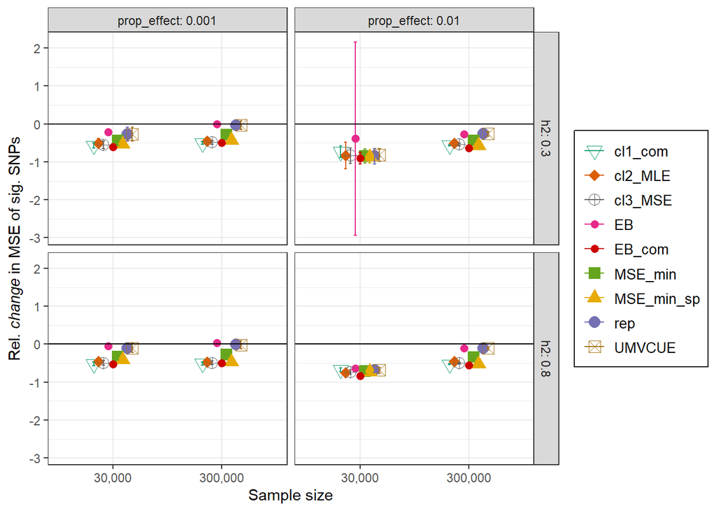

$~$ $~$ $~$ $~$

We also look at how the methods compare when the replication data set is *50%* that of the discovery data set.

Summary of results for `rel_mse` contained in `replicate_norm_5e-8_10sim_halfrep.csv`:

| Scenario | n_samples | h2 | prop_effect | S | EB | rep | UMVCUE | cl1_com | cl2_MLE | cl3_MSE | MSE_min | MSE_min_sp | EB_com |
| --- | --- | --- | --- | --- | --- | --- | --- | --- | --- | --- | --- | --- | --- |
| 1 | 30,000 | 0.3 | 0.010 | -1 | -0.8491 | -0.7975 | -0.5825 | -0.4957 | -0.8334 | -0.8047 | -0.7666 | -0.8031 | -0.9000 |
| 2 | 300,000 | 0.3 | 0.010 | -1 | -0.3099 | 0.4552 | 0.4535 | -0.3920 | -0.2155 | -0.2900 | -0.0130 | -0.3984 | -0.5255 |
| 3 | 30,000 | 0.8 | 0.010 | -1 | -0.6978 | -0.4439 | -0.4450 | -0.4929 | -0.6146 | -0.5995 | -0.5332 | -0.5966 | -0.8082 |
| 4 | 300,000 | 0.8 | 0.010 | -1 | -0.0892 | 0.8687 | 0.8680 | -0.3447 | -0.1509 | -0.2397 | 0.2172 | -0.3417 | -0.3832 |
| 5 | 30,000 | 0.3 | 0.001 | -1 | -0.2418 | 0.4453 | 0.4363 | -0.3984 | -0.2031 | -0.2873 | -0.0324 | -0.3744 | -0.4934 |
| 6 | 300,000 | 0.3 | 0.001 | -1 | 0.0068 | 0.9722 | 0.9568 | -0.3318 | -0.2365 | -0.2849 | 0.2698 | -0.2333 | -0.3261 |
| 7 | 30,000 | 0.8 | 0.001 | -1 | -0.0248 | 0.9187 | 0.9103 | -0.3502 | -0.1467 | -0.2415 | 0.2342 | -0.2185 | -0.3507 |
| 8 | 300,000 | 0.8 | 0.001 | -1 | 0.0338 | 0.9942 | 0.9781 | -0.3389 | -0.2865 | -0.3145 | 0.2832 | -0.2841 | -0.3184 |
| 9 | 30,000 | 0.3 | 0.010 | 0 | -0.3845 | -0.6961 | -0.6381 | -0.5481 | -0.6821 | -0.6996 | -0.7208 | -0.7523 | -0.8726 |
| 10 | 300,000 | 0.3 | 0.010 | 0 | -0.2726 | 0.4759 | 0.4744 | -0.3916 | -0.2176 | -0.2906 | -0.0029 | -0.3920 | -0.5100 |
| 11 | 30,000 | 0.8 | 0.010 | 0 | -0.6448 | -0.3598 | -0.3689 | -0.4861 | -0.5776 | -0.5660 | -0.4838 | -0.5575 | -0.7717 |
| 12 | 300,000 | 0.8 | 0.010 | 0 | -0.1033 | 0.7775 | 0.7766 | -0.3587 | -0.1857 | -0.2655 | 0.1644 | -0.3538 | -0.4030 |
| 13 | 30,000 | 0.3 | 0.001 | 0 | -0.2136 | 0.4694 | 0.4485 | -0.3996 | -0.2143 | -0.2945 | -0.0134 | -0.3175 | -0.4858 |
| 14 | 300,000 | 0.3 | 0.001 | 0 | -0.0051 | 0.9445 | 0.9356 | -0.3373 | -0.2138 | -0.2734 | 0.2568 | -0.1993 | -0.3352 |
| 15 | 30,000 | 0.8 | 0.001 | 0 | -0.0521 | 0.8021 | 0.7923 | -0.3523 | -0.1775 | -0.2573 | 0.1816 | -0.1122 | -0.3672 |
| 16 | 300,000 | 0.8 | 0.001 | 0 | 0.0384 | 0.9731 | 0.9595 | -0.3433 | -0.2519 | -0.2953 | 0.2673 | -0.2715 | -0.3095 |
| 17 | 30,000 | 0.3 | 0.010 | 1 | -0.4004 | -0.6648 | -0.6373 | -0.4951 | -0.7581 | -0.7331 | -0.6554 | -0.6970 | -0.8406 |
| 18 | 300,000 | 0.3 | 0.010 | 1 | -0.2121 | 0.5545 | 0.5530 | -0.3843 | -0.2026 | -0.2814 | 0.0402 | -0.3824 | -0.4764 |
| 19 | 30,000 | 0.8 | 0.010 | 1 | -0.5911 | -0.2340 | -0.2381 | -0.4682 | -0.5090 | -0.5102 | -0.4083 | -0.5120 | -0.7386 |
| 20 | 300,000 | 0.8 | 0.010 | 1 | -0.0756 | 0.8324 | 0.8319 | -0.3510 | -0.1840 | -0.2611 | 0.1957 | -0.3439 | -0.3843 |
| 21 | 30,000 | 0.3 | 0.001 | 1 | -0.1635 | 0.5824 | 0.5611 | -0.3790 | -0.2012 | -0.2816 | 0.0533 | -0.2354 | -0.4380 |
| 22 | 300,000 | 0.3 | 0.001 | 1 | 0.0005 | 0.9175 | 0.9051 | -0.3371 | -0.2280 | -0.2810 | 0.2476 | -0.1533 | -0.3307 |
| 23 | 30,000 | 0.8 | 0.001 | 1 | -0.0101 | 0.8788 | 0.8616 | -0.3454 | -0.1673 | -0.2489 | 0.2237 | -0.0132 | -0.3430 |
| 24 | 300,000 | 0.8 | 0.001 | 1 | 0.0514 | 0.9410 | 0.9213 | -0.3447 | -0.2525 | -0.2955 | 0.2562 | -0.2434 | -0.3153 |

$~$ $~$ $~$ $~$

The *mean* relative change in average MSE over all significant SNPs across the 24 scenarios is obtained for each method:

```
##         EB        rep     UMVCUE    cl1_com    cl2_MLE    cl3_MSE    MSE_min
## -0.2171042  0.4419708  0.4464167 -0.3944333 -0.3212667 -0.3707125 -0.0307750
## MSE_min_sp     EB_com
## -0.3661167 -0.5011417
```

The methods are ranked according to the results above in ascending order:

```
##         EB        rep     UMVCUE    cl1_com    cl2_MLE    cl3_MSE    MSE_min
##          6          8          9          2          5          3          7
## MSE_min_sp     EB_com
##          4          1
```

$~$ $~$ $~$ $~$

*Relative change* **in average MSE over all significant SNPs due to method implementation with a replication GWAS** *50%* **of the size of the discovery GWAS, using a significance threshold of $5 \times 10^{-8}$:**

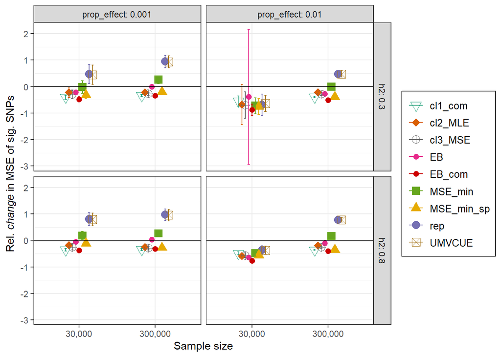

Here, the most interesting point to note is how the empirical Bayes method using just the discovery data set alone behaves better in nearly all of the scenarios compared to UMVCUE, the replication method and the original MSE minimization method. However, again we see a similar pattern to that above in which the empirical Bayes combination method is the clear winner.

$~$ $~$ $~$ $~$

Following this, we look at how the methods compare when the replication data set is *10%* that of the discovery data set.

Summary of results for `rel_mse` contained in `replicate_norm_5e-8_100sim_10pc.csv`:

| Scenario | n_samples | h2 | prop_effect | S | EB | rep | UMVCUE | cl1_com | cl2_MLE | cl3_MSE | MSE_min | MSE_min_sp | EB_com |
| --- | --- | --- | --- | --- | --- | --- | --- | --- | --- | --- | --- | --- | --- |
| 1 | 30,000 | 0.3 | 0.010 | -1 | -0.8491 | 0.0132 | 0.0571 | -0.1341 | -0.6370 | -0.6072 | -0.2379 | -0.3514 | -0.8876 |
| 2 | 300,000 | 0.3 | 0.010 | -1 | -0.3099 | 6.2762 | 6.2524 | -0.1119 | 0.8170 | 0.6367 | 2.8282 | -0.1091 | -0.3659 |
| 3 | 30,000 | 0.8 | 0.010 | -1 | -0.6978 | 1.7822 | 1.7377 | -0.1498 | -0.1169 | -0.1264 | 0.6220 | -0.2253 | -0.7326 |
| 4 | 300,000 | 0.8 | 0.010 | -1 | -0.0892 | 8.3440 | 8.3330 | -0.0936 | 0.7377 | 0.5457 | 3.8270 | -0.0885 | -0.1680 |
| 5 | 30,000 | 0.3 | 0.001 | -1 | -0.2418 | 6.2303 | 6.0580 | -0.1166 | 0.8503 | 0.6614 | 2.7831 | -0.0238 | -0.2971 |
| 6 | 300,000 | 0.3 | 0.001 | -1 | 0.0068 | 8.8616 | 8.6565 | -0.0882 | 0.3166 | 0.2116 | 4.0624 | 0.0997 | -0.0841 |
| 7 | 30,000 | 0.8 | 0.001 | -1 | -0.0248 | 8.5986 | 8.4588 | -0.1007 | 0.7413 | 0.5418 | 3.9308 | 0.1666 | -0.1175 |
| 8 | 300,000 | 0.8 | 0.001 | -1 | 0.0338 | 8.9713 | 8.7455 | -0.0952 | 0.1139 | 0.0571 | 4.1344 | -0.0123 | -0.0731 |
| 9 | 30,000 | 0.3 | 0.010 | 0 | -0.3845 | 0.5205 | 0.9250 | -0.1828 | 0.1251 | 0.0737 | -0.0767 | -0.0933 | -0.6688 |
| 10 | 300,000 | 0.3 | 0.010 | 0 | -0.2726 | 6.3798 | 6.3590 | -0.1126 | 0.7800 | 0.6061 | 2.9044 | -0.1028 | -0.3322 |
| 11 | 30,000 | 0.8 | 0.010 | 0 | -0.6448 | 2.2028 | 2.0978 | -0.1485 | 0.0171 | -0.0002 | 0.8380 | -0.1962 | -0.6935 |
| 12 | 300,000 | 0.8 | 0.010 | 0 | -0.1033 | 7.8881 | 7.8751 | -0.1006 | 0.6774 | 0.4998 | 3.6148 | -0.0946 | -0.1848 |
| 13 | 30,000 | 0.3 | 0.001 | 0 | -0.2136 | 6.3507 | 6.0972 | -0.1189 | 0.7971 | 0.6164 | 2.8699 | 0.1077 | -0.2790 |
| 14 | 300,000 | 0.3 | 0.001 | 0 | -0.0051 | 8.7229 | 8.5797 | -0.0913 | 0.4285 | 0.2991 | 4.0346 | 0.1491 | -0.0934 |
| 15 | 30,000 | 0.8 | 0.001 | 0 | -0.0521 | 8.0151 | 7.8674 | -0.0965 | 0.6857 | 0.5077 | 3.7033 | 0.4459 | -0.1304 |
| 16 | 300,000 | 0.8 | 0.001 | 0 | 0.0384 | 8.8660 | 8.6681 | -0.0978 | 0.2605 | 0.1719 | 4.0711 | 0.0087 | -0.0602 |
| 17 | 30,000 | 0.3 | 0.010 | 1 | -0.4004 | 0.6771 | 0.8672 | -0.1403 | -0.3788 | -0.3823 | 0.0308 | -0.0732 | -0.5952 |
| 18 | 300,000 | 0.3 | 0.010 | 1 | -0.2121 | 6.7731 | 6.7507 | -0.1105 | 0.7762 | 0.5931 | 3.0734 | -0.0979 | -0.2859 |
| 19 | 30,000 | 0.8 | 0.010 | 1 | -0.5911 | 2.8319 | 2.7641 | -0.1400 | 0.1656 | 0.1217 | 1.1676 | -0.1639 | -0.6372 |
| 20 | 300,000 | 0.8 | 0.010 | 1 | -0.0756 | 8.1626 | 8.1497 | -0.0970 | 0.6370 | 0.4671 | 3.7499 | -0.0885 | -0.1595 |
| 21 | 30,000 | 0.3 | 0.001 | 1 | -0.1635 | 6.9164 | 6.6568 | -0.1075 | 0.7734 | 0.5901 | 3.1562 | 0.2822 | -0.2274 |
| 22 | 300,000 | 0.3 | 0.001 | 1 | 0.0005 | 8.5880 | 8.3793 | -0.0898 | 0.3701 | 0.2563 | 3.9705 | 0.2507 | -0.0884 |
| 23 | 30,000 | 0.8 | 0.001 | 1 | -0.0101 | 8.3988 | 8.1694 | -0.0947 | 0.6833 | 0.5017 | 3.8652 | 0.6957 | -0.1001 |
| 24 | 300,000 | 0.8 | 0.001 | 1 | 0.0514 | 8.7056 | 8.4219 | -0.0974 | 0.2634 | 0.1771 | 4.0170 | 0.0538 | -0.0488 |

$~$ $~$ $~$ $~$

The *mean* relative change in average MSE over all significant SNPs across the 24 scenarios is obtained for each method:

```
##          EB         rep      UMVCUE     cl1_com     cl2_MLE     cl3_MSE
## -0.21710417  6.21153333  6.12197500 -0.11317917  0.41185417  0.29250000
##     MSE_min  MSE_min_sp      EB_com
##  2.78916667  0.02247083 -0.30461250
```

The methods are ranked according to the results above in ascending order:

```
##         EB        rep     UMVCUE    cl1_com    cl2_MLE    cl3_MSE    MSE_min
##          2          9          8          3          6          5          7
## MSE_min_sp     EB_com
##          4          1
```

$~$ $~$ $~$ $~$

*Relative change* **in average MSE over all significant SNPs due to method implementation with a replication GWAS** *10%* **of the size of the discovery GWAS, using a significance threshold of $5 \times 10^{-8}$:**

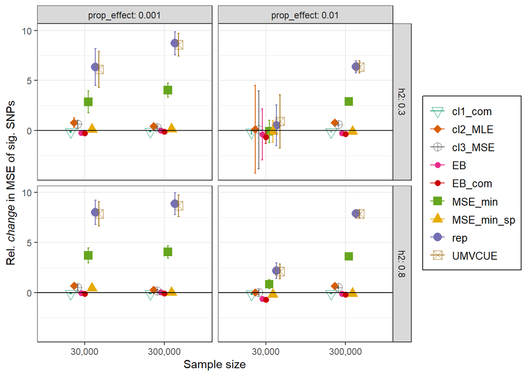

In this situation, the empirical Bayes method tends to behave better than all of the other methods bar the empirical Bayes combination method. This suggests that if a replication data set is available, we must take into account the size of it relative to the discovery GWAS. If it is a lot smaller, using just the replication GWAS to obtain more accurate effect size estimates is certainly inadvisable. One should at the very least consider obtaining $(\hat\beta_{\text{com}}, \sigma_{\text{com}})$, this is the method named `cl1_com`.

$~$ $~$ $~$ $~$

In addition, we look at how the methods compare when the replication data set is *twice* that of the discovery data set in which we see that the results are very similar to those obtained when the two data sets are of a similar size.

Summary of results for `rel_mse` contained in `replicate_norm_5e-8_100sim_2.csv`:

| Scenario | n_samples | h2 | prop_effect | S | EB | rep | UMVCUE | cl1_com | cl2_MLE | cl3_MSE | MSE_min | MSE_min_sp | EB_com |
| --- | --- | --- | --- | --- | --- | --- | --- | --- | --- | --- | --- | --- | --- |
| 1 | 30,000 | 0.3 | 0.010 | -1 | -0.8491 | -0.9494 | -0.8762 | -0.8477 | -0.9497 | -0.9340 | -0.9397 | -0.9437 | -0.9540 |
| 2 | 300,000 | 0.3 | 0.010 | -1 | -0.3099 | -0.6362 | -0.6364 | -0.7263 | -0.7099 | -0.7259 | -0.6890 | -0.7299 | -0.7592 |
| 3 | 30,000 | 0.8 | 0.010 | -1 | -0.6978 | -0.8610 | -0.8609 | -0.8267 | -0.8753 | -0.8654 | -0.8605 | -0.8658 | -0.9076 |
| 4 | 300,000 | 0.8 | 0.010 | -1 | -0.0892 | -0.5328 | -0.5329 | -0.6796 | -0.6523 | -0.6734 | -0.6122 | -0.6791 | -0.6891 |
| 5 | 30,000 | 0.3 | 0.001 | -1 | -0.2418 | -0.6387 | -0.6390 | -0.7300 | -0.7084 | -0.7292 | -0.6922 | -0.7287 | -0.7445 |
| 6 | 300,000 | 0.3 | 0.001 | -1 | 0.0068 | -0.5070 | -0.5085 | -0.6675 | -0.6531 | -0.6645 | -0.5939 | -0.6468 | -0.6646 |
| 7 | 30,000 | 0.8 | 0.001 | -1 | -0.0248 | -0.5204 | -0.5210 | -0.6796 | -0.6483 | -0.6722 | -0.6053 | -0.6522 | -0.6765 |
| 8 | 300,000 | 0.8 | 0.001 | -1 | 0.0338 | -0.5015 | -0.5029 | -0.6698 | -0.6456 | -0.6592 | -0.5911 | -0.6568 | -0.6642 |
| 9 | 30,000 | 0.3 | 0.010 | 0 | -0.3845 | -0.9240 | -0.9106 | -0.8683 | -0.9158 | -0.9191 | -0.9242 | -0.9301 | -0.9349 |
| 10 | 300,000 | 0.3 | 0.010 | 0 | -0.2726 | -0.6310 | -0.6311 | -0.7249 | -0.7080 | -0.7243 | -0.6857 | -0.7265 | -0.7540 |
| 11 | 30,000 | 0.8 | 0.010 | 0 | -0.6448 | -0.8400 | -0.8409 | -0.8186 | -0.8603 | -0.8514 | -0.8453 | -0.8464 | -0.8898 |
| 12 | 300,000 | 0.8 | 0.010 | 0 | -0.1033 | -0.5556 | -0.5557 | -0.6917 | -0.6690 | -0.6875 | -0.6297 | -0.6905 | -0.7021 |
| 13 | 30,000 | 0.3 | 0.001 | 0 | -0.2136 | -0.6327 | -0.6350 | -0.7293 | -0.7079 | -0.7280 | -0.6885 | -0.7152 | -0.7418 |
| 14 | 300,000 | 0.3 | 0.001 | 0 | -0.0051 | -0.5139 | -0.5145 | -0.6717 | -0.6529 | -0.6676 | -0.6002 | -0.6415 | -0.6666 |
| 15 | 30,000 | 0.8 | 0.001 | 0 | -0.0521 | -0.5495 | -0.5503 | -0.6872 | -0.6648 | -0.6833 | -0.6248 | -0.6437 | -0.6917 |
| 16 | 300,000 | 0.8 | 0.001 | 0 | 0.0384 | -0.5067 | -0.5079 | -0.6731 | -0.6466 | -0.6626 | -0.5956 | -0.6560 | -0.6641 |
| 17 | 30,000 | 0.3 | 0.010 | 1 | -0.4004 | -0.9162 | -0.9006 | -0.8401 | -0.9240 | -0.9080 | -0.9061 | -0.9032 | -0.9325 |
| 18 | 300,000 | 0.3 | 0.010 | 1 | -0.2121 | -0.6114 | -0.6115 | -0.7169 | -0.6966 | -0.7145 | -0.6710 | -0.7175 | -0.7387 |
| 19 | 30,000 | 0.8 | 0.010 | 1 | -0.5911 | -0.8085 | -0.8087 | -0.8027 | -0.8338 | -0.8282 | -0.8194 | -0.8198 | -0.8679 |
| 20 | 300,000 | 0.8 | 0.010 | 1 | -0.0756 | -0.5419 | -0.5419 | -0.6848 | -0.6623 | -0.6805 | -0.6195 | -0.6829 | -0.6919 |
| 21 | 30,000 | 0.3 | 0.001 | 1 | -0.1635 | -0.6044 | -0.6068 | -0.7127 | -0.6926 | -0.7113 | -0.6662 | -0.6906 | -0.7239 |
| 22 | 300,000 | 0.3 | 0.001 | 1 | 0.0005 | -0.5206 | -0.5213 | -0.6731 | -0.6559 | -0.6694 | -0.6032 | -0.6363 | -0.6641 |
| 23 | 30,000 | 0.8 | 0.001 | 1 | -0.0101 | -0.5304 | -0.5320 | -0.6794 | -0.6556 | -0.6747 | -0.6113 | -0.6200 | -0.6791 |
| 24 | 300,000 | 0.8 | 0.001 | 1 | 0.0514 | -0.5147 | -0.5164 | -0.6756 | -0.6461 | -0.6633 | -0.6005 | -0.6520 | -0.6617 |

$~$ $~$ $~$ $~$

The *mean* relative change in average MSE over all significant SNPs across the 24 scenarios is obtained for each method:

```
##         EB        rep     UMVCUE    cl1_com    cl2_MLE    cl3_MSE    MSE_min
## -0.2171042 -0.6395208 -0.6359583 -0.7282208 -0.7264500 -0.7373958 -0.6947958
## MSE_min_sp     EB_com
## -0.7281333 -0.7526875
```

The methods are ranked according to the results above in ascending order:

```
##         EB        rep     UMVCUE    cl1_com    cl2_MLE    cl3_MSE    MSE_min
##          9          7          8          3          5          2          6
## MSE_min_sp     EB_com
##          4          1
```

$~$ $~$ $~$ $~$

*Relative change* **in average MSE over all significant SNPs due to method implementation with a replication GWAS** *twice* **the size of the discovery GWAS, using a significance threshold of $5 \times 10^{-8}$:**

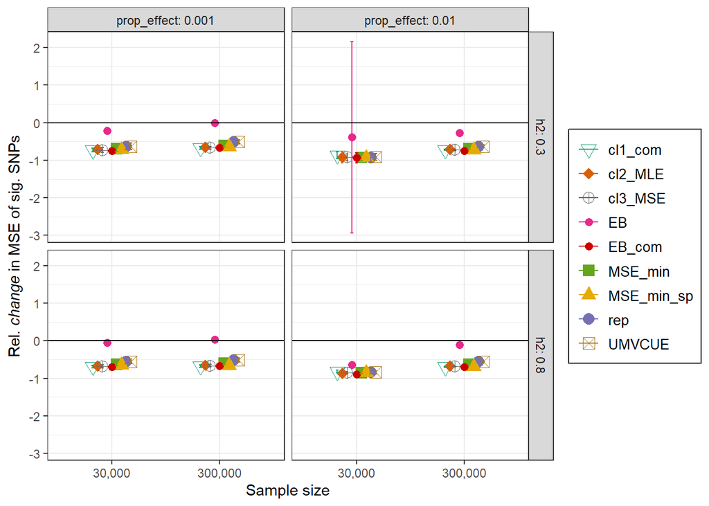

$~$ $~$ $~$ $~$

As the next step in this section, we investigate the behaviour of methods when the replication and discovery GWASs are of *equal size* and the effect sizes follow the previously described *bimodal* distribution.

Summary of results for `rel_mse` contained in `replicate_bim_5e-8_100sim.csv`:

| Scenario | n_samples | h2 | prop_effect | S | EB | rep | UMVCUE | cl1_com | cl2_MLE | cl3_MSE | MSE_min | MSE_min_sp | EB_com |
| --- | --- | --- | --- | --- | --- | --- | --- | --- | --- | --- | --- | --- | --- |
| 1 | 30,000 | 0.3 | 0.010 | -1 | -0.9352 | -0.9254 | -0.7445 | -0.7067 | -0.9312 | -0.9131 | -0.9045 | -0.9186 | -0.9471 |
| 2 | 300,000 | 0.3 | 0.010 | -1 | -0.3994 | -0.3370 | -0.3371 | -0.5825 | -0.5326 | -0.5640 | -0.4796 | -0.5932 | -0.6802 |
| 3 | 30,000 | 0.8 | 0.010 | -1 | -0.7847 | -0.7716 | -0.7733 | -0.6838 | -0.8103 | -0.7866 | -0.7695 | -0.7878 | -0.8908 |
| 4 | 300,000 | 0.8 | 0.010 | -1 | -0.1256 | -0.0907 | -0.0908 | -0.5213 | -0.4383 | -0.4882 | -0.3224 | -0.5186 | -0.5525 |
| 5 | 30,000 | 0.3 | 0.001 | -1 | -0.2322 | -0.3177 | -0.3223 | -0.5926 | -0.5197 | -0.5602 | -0.4732 | -0.5869 | -0.6610 |
| 6 | 300,000 | 0.3 | 0.001 | -1 | -0.0020 | -0.0081 | -0.0090 | -0.5016 | -0.4544 | -0.4846 | -0.2728 | -0.4543 | -0.4992 |
| 7 | 30,000 | 0.8 | 0.001 | -1 | -0.0721 | -0.0735 | -0.0749 | -0.5198 | -0.4350 | -0.4879 | -0.3185 | -0.4716 | -0.5320 |
| 8 | 300,000 | 0.8 | 0.001 | -1 | 0.0165 | -0.0135 | -0.0166 | -0.5057 | -0.4798 | -0.4969 | -0.2764 | -0.4683 | -0.4940 |
| 9 | 30,000 | 0.3 | 0.010 | 0 | -0.9359 | -0.9355 | -0.7662 | -0.7368 | -0.9493 | -0.9384 | -0.9242 | -0.9359 | -0.9528 |
| 10 | 300,000 | 0.3 | 0.010 | 0 | -0.4005 | -0.3100 | -0.3104 | -0.5771 | -0.5178 | -0.5532 | -0.4634 | -0.5893 | -0.6740 |
| 11 | 30,000 | 0.8 | 0.010 | 0 | -0.8270 | -0.8071 | -0.8076 | -0.7034 | -0.8363 | -0.8165 | -0.8012 | -0.8259 | -0.9163 |
| 12 | 300,000 | 0.8 | 0.010 | 0 | -0.1113 | -0.0906 | -0.0906 | -0.5218 | -0.4454 | -0.4933 | -0.3237 | -0.5193 | -0.5497 |
| 13 | 30,000 | 0.3 | 0.001 | 0 | -0.3019 | -0.2560 | -0.2594 | -0.5649 | -0.4833 | -0.5307 | -0.4266 | -0.5579 | -0.6165 |
| 14 | 300,000 | 0.3 | 0.001 | 0 | -0.0055 | -0.0216 | -0.0234 | -0.5044 | -0.4569 | -0.4865 | -0.2816 | -0.4595 | -0.5039 |
| 15 | 30,000 | 0.8 | 0.001 | 0 | -0.0752 | -0.0821 | -0.0837 | -0.5182 | -0.4437 | -0.4900 | -0.3189 | -0.4558 | -0.5365 |
| 16 | 300,000 | 0.8 | 0.001 | 0 | 0.0021 | -0.0037 | -0.0059 | -0.5016 | -0.4649 | -0.4890 | -0.2700 | -0.4607 | -0.4973 |
| 17 | 30,000 | 0.3 | 0.010 | 1 | -0.9399 | -0.9492 | -0.7926 | -0.7504 | -0.9553 | -0.9492 | -0.9435 | -0.9552 | -0.9682 |
| 18 | 300,000 | 0.3 | 0.010 | 1 | -0.4882 | -0.3462 | -0.3464 | -0.5848 | -0.5289 | -0.5593 | -0.4852 | -0.6019 | -0.7125 |
| 19 | 30,000 | 0.8 | 0.010 | 1 | -0.8437 | -0.8475 | -0.8470 | -0.7150 | -0.8698 | -0.8501 | -0.8343 | -0.8609 | -0.9333 |
| 20 | 300,000 | 0.8 | 0.010 | 1 | -0.1136 | -0.0644 | -0.0644 | -0.5159 | -0.4287 | -0.4822 | -0.3075 | -0.5133 | -0.5450 |
| 21 | 30,000 | 0.3 | 0.001 | 1 | -0.4344 | -0.3418 | -0.3434 | -0.5849 | -0.5357 | -0.5657 | -0.4834 | -0.5930 | -0.6860 |
| 22 | 300,000 | 0.3 | 0.001 | 1 | -0.0087 | -0.0361 | -0.0373 | -0.5083 | -0.4664 | -0.4929 | -0.2902 | -0.4716 | -0.5088 |
| 23 | 30,000 | 0.8 | 0.001 | 1 | -0.0442 | -0.0622 | -0.0628 | -0.5197 | -0.4299 | -0.4850 | -0.3108 | -0.4612 | -0.5279 |
| 24 | 300,000 | 0.8 | 0.001 | 1 | -0.0004 | -0.0114 | -0.0138 | -0.5040 | -0.4669 | -0.4899 | -0.2765 | -0.4770 | -0.5021 |

$~$ $~$ $~$ $~$

The *mean* relative change in average MSE over all significant SNPs across the 24 scenarios is obtained for each method:

```
##         EB        rep     UMVCUE    cl1_com    cl2_MLE    cl3_MSE    MSE_min
## -0.3359583 -0.3209542 -0.3009750 -0.5802167 -0.5783542 -0.6022250 -0.4815792
## MSE_min_sp     EB_com
## -0.6057375 -0.6619833
```

The methods are ranked according to the results above in ascending order:

```
##         EB        rep     UMVCUE    cl1_com    cl2_MLE    cl3_MSE    MSE_min
##          7          8          9          4          5          3          6
## MSE_min_sp     EB_com
##          2          1
```

$~$ $~$ $~$ $~$

*Relative change* **in average MSE over all significant SNPs due to method implementation with a replication and discovery GWAS of** *equal* **size, using a significance threshold of $5 \times 10^{-8}$ and a** *bimodal* **distribution of effect sizes:**

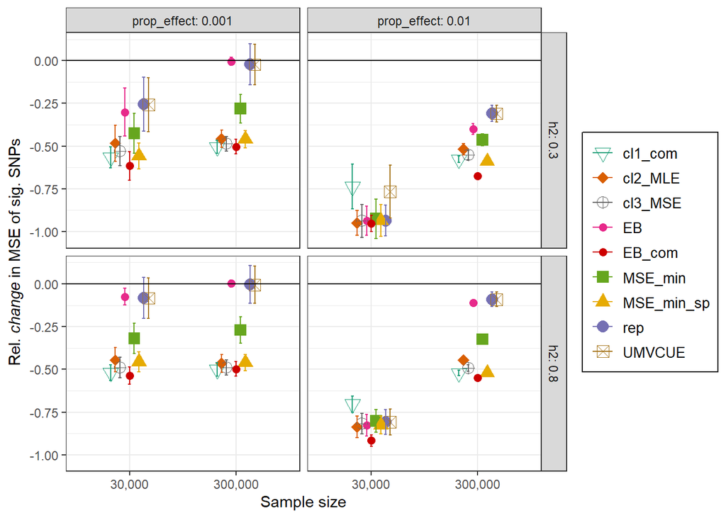

$~$ $~$

The fact that the results here remain quite similar to those that we viewed previously under a normal distribution of true effect sizes is reassuring. In fact, we note the slightly improved performance of the empirical Bayes method which uses only the discovery GWAS with this bimodal distribution. Again, the combined empirical Bayes approach makes the greatest improvement to the average MSE of significant SNPs in almost all scenarios while the UMVCUE method continues to behave in a very similar manner to using only the replication GWAS to obtain estimates for the effect sizes.

$~$ $~$ $~$ $~$

### 8. Winner’s Curse and Binary Traits

Under the same 24 scenarios, we investigate simulating summary statistics for a binary trait with disease prevalence of 0.1 and the corresponding performance of the various Winner’s Curse adjustment methods. Below is a summary of the results contained in `binary_norm_nsig_prop_bias_5e-8_10sim.csv` and `binary_norm_nsig_prop_bias_5e-4_10sim.csv`. Compared to the quantitative trait above, we witness a lot less SNPs meeting the significance threshold of `5e-8` under many of the scenarios.

Details as to how we have simulated this binary trait can be found in `binary_traits.R`. However, it is worth noting that it can be very computationally intensive and hence why our investigation here has been restricted to a mere total of 10 simulations for each scenario. The reason for this being that given values for the true effect size of a SNP, $\beta$ and its minor allele frequency, we must also simulate a value $\beta_0$ in order to obtain an appropriate value for $\text{se}(\hat\beta)$. Our grid-like set-up has reduced the computing time immensely but in comparison to simulating a quantitative trait, it still takes considerably longer.

| Scenario | n_samples | h2 | prop_effect | S | n_sig 5e-8 | prop_bias 5e-8 | prop_x 5e-8 | mse 5e-8 | n_sig 5e-4 | prop_bias 5e-4 | prop_x 5e-4 | mse 5e-4 | sd(n_sig) 5e-8 | sd(prop_bias) 5e-8 | sd(prop_x) 5e-8 | sd(mse) 5e-8 | sd(n_sig) 5e-4 | sd(prop_bias) 5e-4 | sd(prop_x) 5e-4 | sd(mse) 5e-4 |
| --- | --- | --- | --- | --- | --- | --- | --- | --- | --- | --- | --- | --- | --- | --- | --- | --- | --- | --- | --- | --- |
| 1 | 30,000 | 0.3 | 0.010 | -1 | 0.1 | 1.0000 | 1.0000 | 0.043205 | 503.2 | 1.0000 | 1.0000 | 0.024306 | 0.316 | NA | NA | NA | 19.384 | 0.0000 | 0.0000 | 0.001972 |
| 2 | 300,000 | 0.3 | 0.010 | -1 | 0.4 | 1.0000 | 1.0000 | 0.001337 | 563.2 | 1.0000 | 0.9590 | 0.002258 | 0.516 | 0.0000 | 0.0000 | 0.000347 | 23.748 | 0.0000 | 0.0107 | 0.000134 |
| 3 | 30,000 | 0.8 | 0.010 | -1 | 2.3 | 1.0000 | 0.6667 | 0.018844 | 687.4 | 0.9960 | 0.8229 | 0.019493 | 1.337 | 0.0000 | 0.2976 | 0.009237 | 17.658 | 0.0028 | 0.0173 | 0.001161 |
| 4 | 300,000 | 0.8 | 0.010 | -1 | 1353.9 | 0.7098 | 0.0732 | 0.000215 | 3870.3 | 0.7067 | 0.1751 | 0.000481 | 16.749 | 0.0106 | 0.0058 | 0.000011 | 44.672 | 0.0067 | 0.0044 | 0.000016 |
| 5 | 30,000 | 0.3 | 0.001 | -1 | 0.2 | 1.0000 | 1.0000 | 0.023959 | 510.7 | 1.0000 | 0.9934 | 0.024185 | 0.422 | 0.0000 | 0.0000 | 0.011519 | 19.568 | 0.0000 | 0.0029 | 0.000956 |
| 6 | 300,000 | 0.3 | 0.001 | -1 | 51.5 | 0.7965 | 0.1205 | 0.000298 | 713.3 | 0.9227 | 0.7224 | 0.001781 | 5.339 | 0.0565 | 0.0552 | 0.000110 | 28.960 | 0.0073 | 0.0099 | 0.000106 |
| 7 | 30,000 | 0.8 | 0.001 | -1 | 130.2 | 0.7189 | 0.0761 | 0.002359 | 834.1 | 0.8651 | 0.6177 | 0.015121 | 7.657 | 0.0337 | 0.0238 | 0.000643 | 28.097 | 0.0080 | 0.0168 | 0.000689 |
| 8 | 300,000 | 0.8 | 0.001 | -1 | 626.3 | 0.5347 | 0.0336 | 0.000186 | 1251.8 | 0.7170 | 0.4159 | 0.001057 | 17.982 | 0.0182 | 0.0052 | 0.000015 | 30.025 | 0.0117 | 0.0109 | 0.000059 |
| 9 | 30,000 | 0.3 | 0.010 | 0 | 0.1 | 1.0000 | 1.0000 | 0.031993 | 498.8 | 1.0000 | 1.0000 | 0.024378 | 0.316 | NA | NA | NA | 16.518 | 0.0000 | 0.0000 | 0.000919 |
| 10 | 300,000 | 0.3 | 0.010 | 0 | 0.3 | 1.0000 | 1.0000 | 0.001994 | 580.4 | 0.9998 | 0.9448 | 0.002149 | 0.483 | 0.0000 | 0.0000 | 0.002061 | 31.178 | 0.0005 | 0.0120 | 0.000140 |
| 11 | 30,000 | 0.8 | 0.010 | 0 | 5.3 | 0.9833 | 0.4772 | 0.003954 | 718.3 | 0.9925 | 0.7883 | 0.017537 | 2.111 | 0.0527 | 0.2430 | 0.001587 | 25.755 | 0.0032 | 0.0111 | 0.000823 |
| 12 | 300,000 | 0.8 | 0.010 | 0 | 1338.0 | 0.6829 | 0.0664 | 0.000120 | 3678.1 | 0.7050 | 0.1873 | 0.000463 | 22.376 | 0.0124 | 0.0047 | 0.000006 | 20.739 | 0.0059 | 0.0066 | 0.000024 |
| 13 | 30,000 | 0.3 | 0.001 | 0 | 0.0 | NA | NA | NA | 514.1 | 1.0000 | 0.9941 | 0.023966 | 0.000 | NA | NA | NA | 11.930 | 0.0000 | 0.0033 | 0.000874 |
| 14 | 300,000 | 0.3 | 0.001 | 0 | 56.4 | 0.7825 | 0.1075 | 0.000141 | 703.9 | 0.9209 | 0.7296 | 0.001785 | 5.661 | 0.0628 | 0.0393 | 0.000030 | 24.016 | 0.0068 | 0.0113 | 0.000134 |
| 15 | 30,000 | 0.8 | 0.001 | 0 | 130.3 | 0.6866 | 0.0622 | 0.001186 | 816.3 | 0.8683 | 0.6312 | 0.015436 | 8.111 | 0.0497 | 0.0275 | 0.000160 | 16.180 | 0.0073 | 0.0160 | 0.000864 |
| 16 | 300,000 | 0.8 | 0.001 | 0 | 585.6 | 0.5541 | 0.0330 | 0.000133 | 1218.8 | 0.7286 | 0.4246 | 0.001058 | 15.785 | 0.0179 | 0.0082 | 0.000013 | 20.115 | 0.0112 | 0.0155 | 0.000067 |
| 17 | 30,000 | 0.3 | 0.010 | 1 | 0.1 | 1.0000 | 1.0000 | 0.029079 | 505.2 | 1.0000 | 1.0000 | 0.024162 | 0.316 | NA | NA | NA | 15.259 | 0.0000 | 0.0000 | 0.001306 |
| 18 | 300,000 | 0.3 | 0.010 | 1 | 0.6 | 1.0000 | 0.8750 | 0.001202 | 580.7 | 0.9991 | 0.9277 | 0.002092 | 0.843 | 0.0000 | 0.2500 | 0.000601 | 20.907 | 0.0012 | 0.0087 | 0.000144 |
| 19 | 30,000 | 0.8 | 0.010 | 1 | 8.0 | 0.9546 | 0.3713 | 0.003110 | 730.7 | 0.9851 | 0.7653 | 0.017206 | 2.582 | 0.0761 | 0.2686 | 0.001241 | 26.779 | 0.0045 | 0.0202 | 0.001488 |
| 20 | 300,000 | 0.8 | 0.010 | 1 | 1343.7 | 0.6683 | 0.0574 | 0.000101 | 3445.6 | 0.6977 | 0.1899 | 0.000435 | 26.030 | 0.0139 | 0.0062 | 0.000003 | 42.717 | 0.0110 | 0.0075 | 0.000024 |
| 21 | 30,000 | 0.3 | 0.001 | 1 | 0.1 | 1.0000 | 1.0000 | 0.028158 | 502.1 | 0.9998 | 0.9924 | 0.023958 | 0.316 | NA | NA | NA | 22.951 | 0.0006 | 0.0037 | 0.001363 |
| 22 | 300,000 | 0.3 | 0.001 | 1 | 64.5 | 0.7587 | 0.0862 | 0.000115 | 697.8 | 0.9203 | 0.7345 | 0.001734 | 6.654 | 0.0399 | 0.0416 | 0.000032 | 28.142 | 0.0122 | 0.0132 | 0.000078 |
| 23 | 30,000 | 0.8 | 0.001 | 1 | 134.2 | 0.6752 | 0.0730 | 0.001053 | 793.5 | 0.8737 | 0.6537 | 0.016008 | 5.903 | 0.0244 | 0.0277 | 0.000162 | 21.629 | 0.0085 | 0.0167 | 0.000750 |
| 24 | 300,000 | 0.8 | 0.001 | 1 | 532.7 | 0.5474 | 0.0316 | 0.000106 | 1159.1 | 0.7369 | 0.4396 | 0.001107 | 12.763 | 0.0103 | 0.0064 | 0.000010 | 18.806 | 0.0080 | 0.0085 | 0.000067 |

$~$ $~$ $~$ $~$

We plot $z$ vs $\text{bias}$ for the 24 different scenarios with a simulated binary trait. Similar to above, the points corresponding to SNPs which are *significantly* biased and are significant at a threshold of $5 \times 10^{-4}$ are coloured in navy .

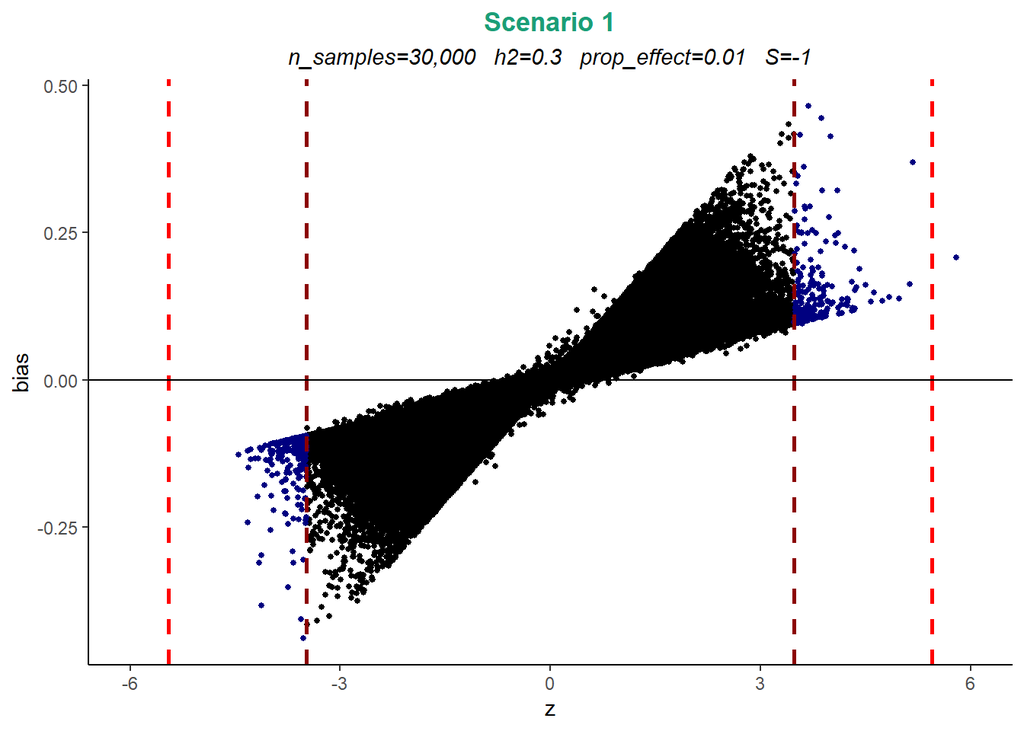

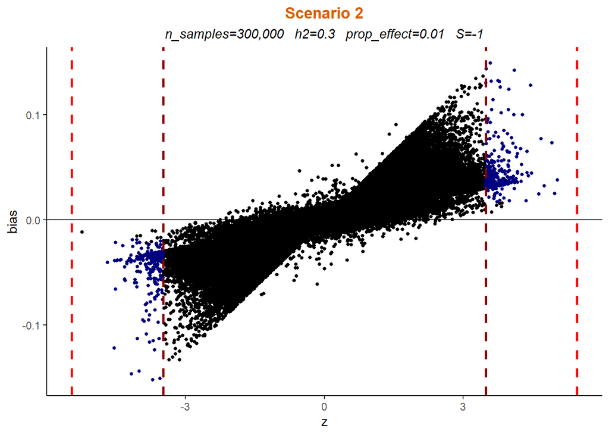

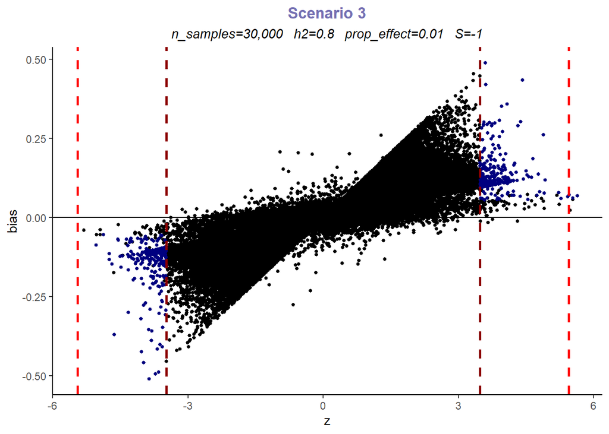

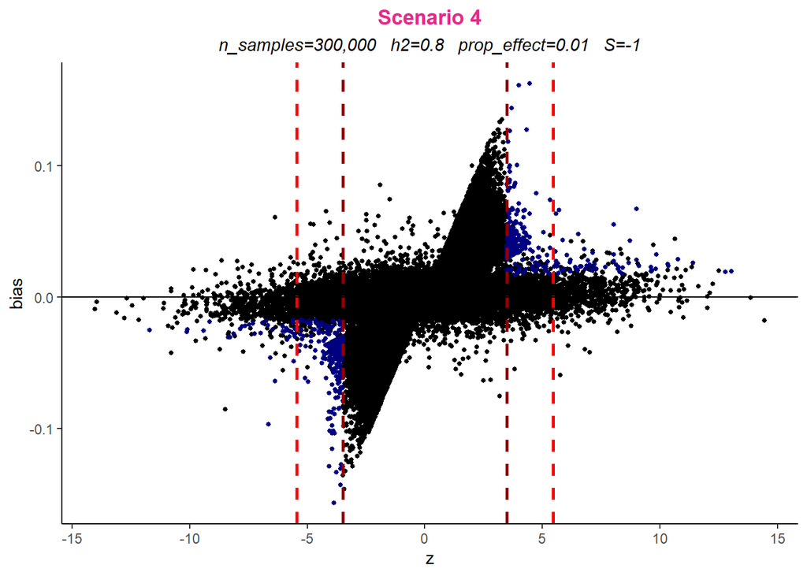

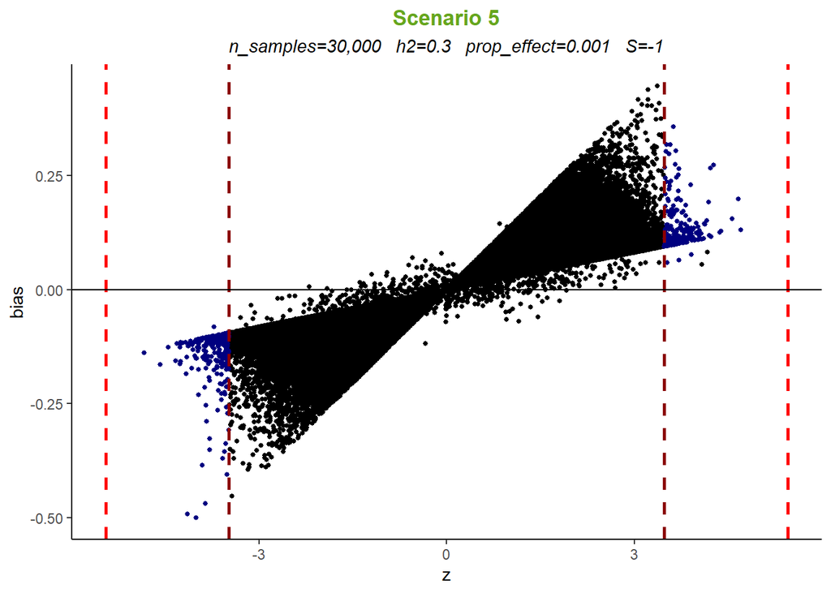

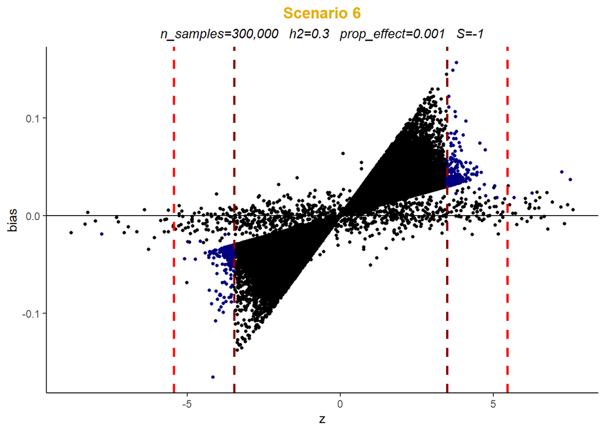

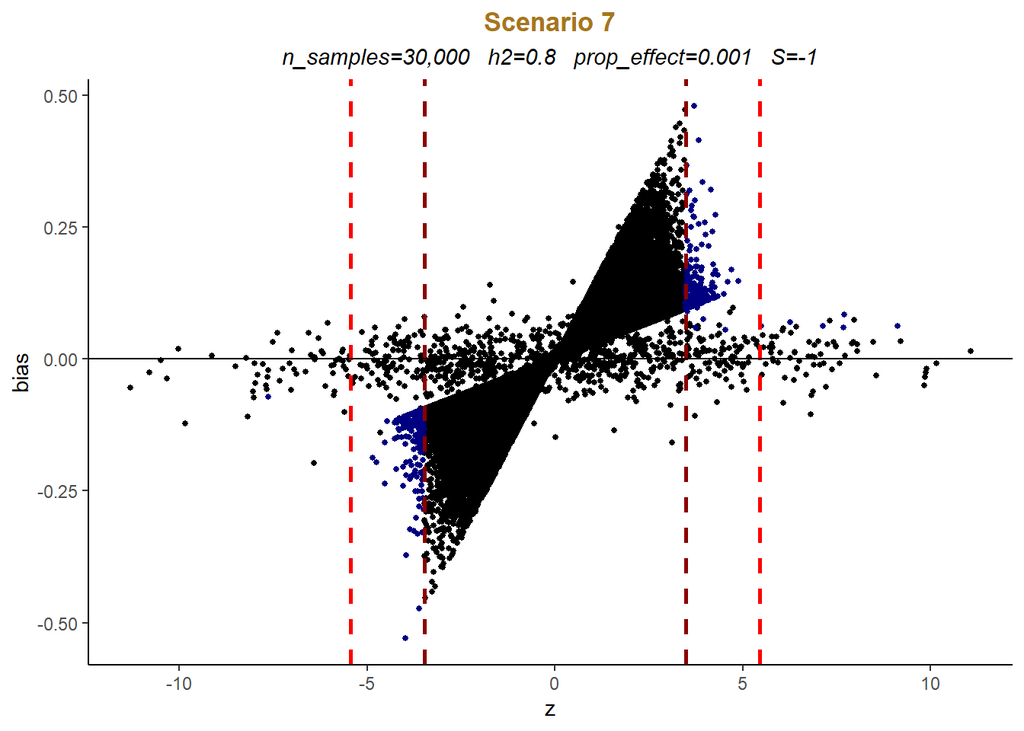

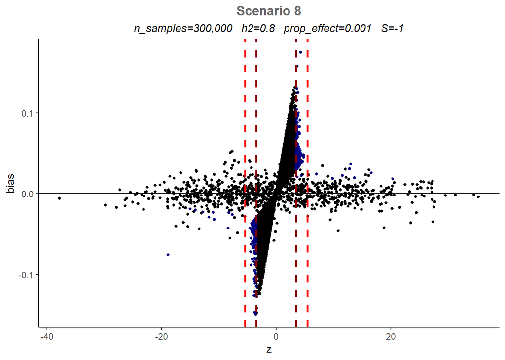

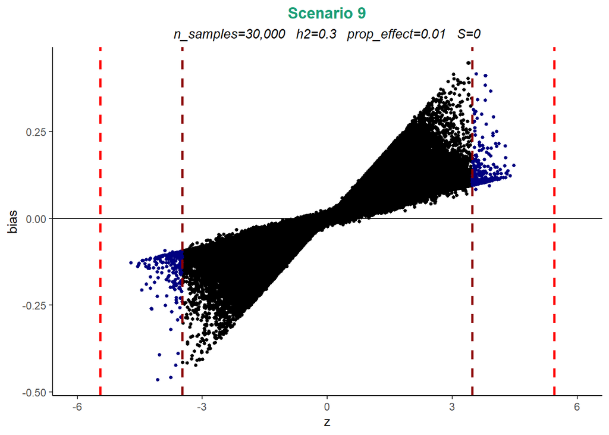

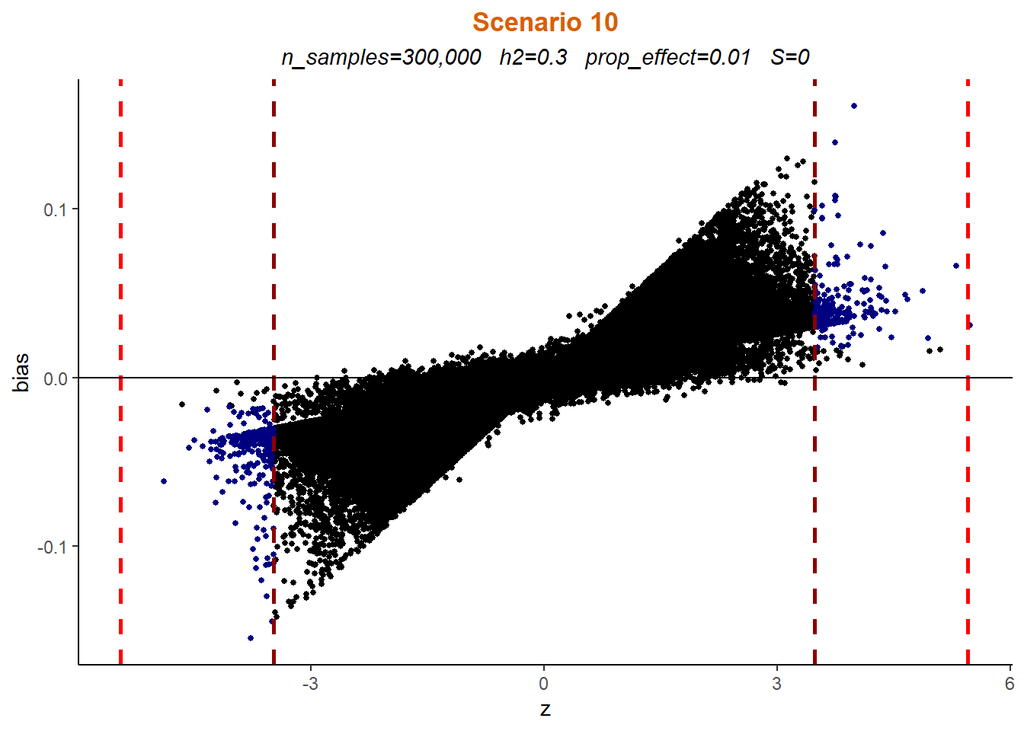

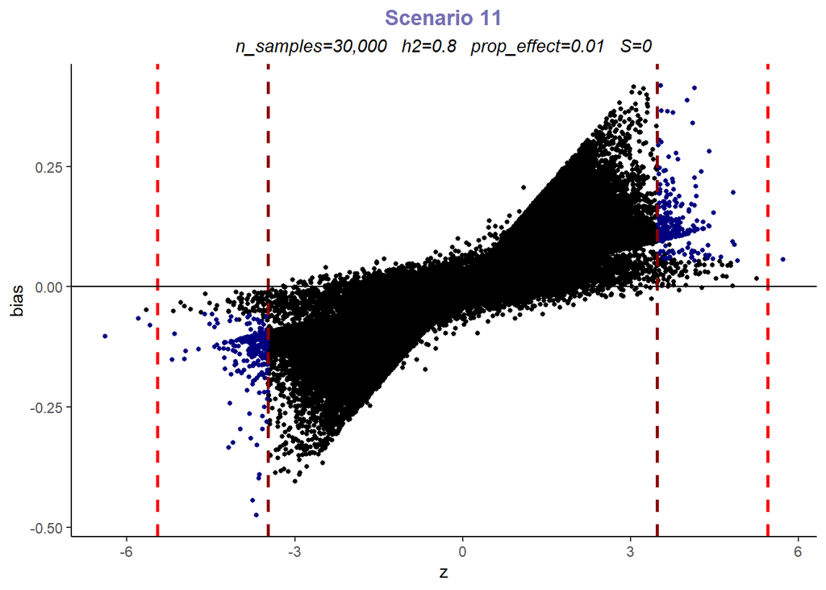

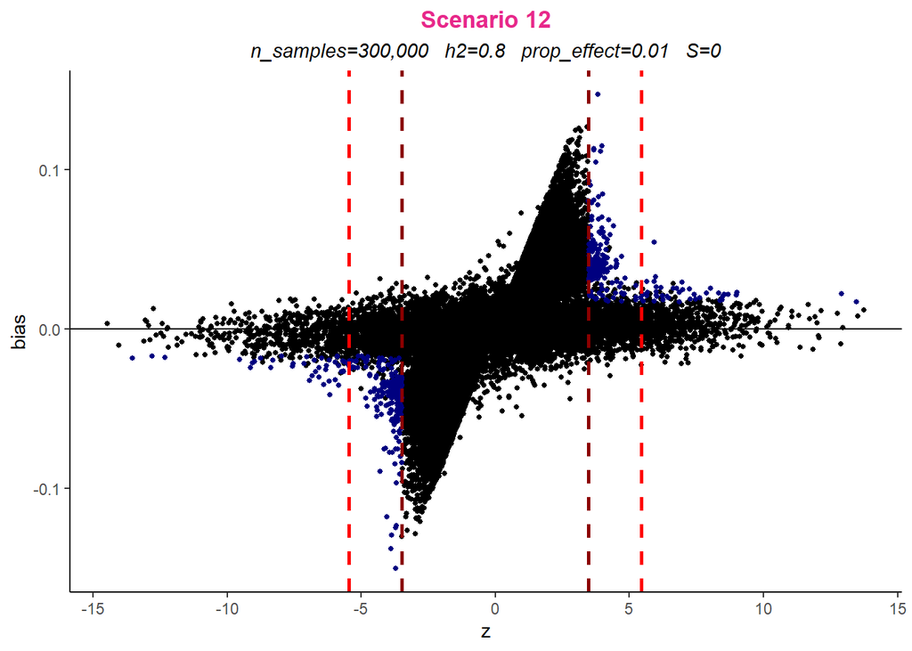

[12 more figures not shown]

$~$ $~$ $~$ $~$

Summary of results for `rel_mse` contained in `binary_norm_5e-8_10sim.csv`:

| Scenario | n_samples | h2 | prop_effect | S | EB | FIQT | BR | cl1 | cl2 | cl3 | rep |
| --- | --- | --- | --- | --- | --- | --- | --- | --- | --- | --- | --- |
| 1 | 30,000 | 0.3 | 0.010 | -1 | -0.8321 | -0.7771 | -0.9121 | -0.6689 | -0.6791 | -0.6746 | -0.9954 |
| 2 | 300,000 | 0.3 | 0.010 | -1 | -0.9371 | -0.9499 | -0.8904 | -0.7777 | -0.9229 | -0.8986 | -0.9533 |
| 3 | 30,000 | 0.8 | 0.010 | -1 | -0.7689 | -0.7803 | -0.7013 | -0.0147 | -0.7514 | -0.4770 | -0.8230 |
| 4 | 300,000 | 0.8 | 0.010 | -1 | -0.2148 | 0.1763 | -0.0974 | 2.4029 | 1.1847 | 1.6734 | -0.2074 |
| 5 | 30,000 | 0.3 | 0.001 | -1 | -0.8933 | -0.8504 | -0.9085 | -0.9945 | -0.8166 | -0.9368 | -0.9954 |
| 6 | 300,000 | 0.3 | 0.001 | -1 | -0.2884 | 0.6545 | 0.4088 | 2.4080 | 0.9838 | 1.5630 | -0.3425 |
| 7 | 30,000 | 0.8 | 0.001 | -1 | -0.1623 | 1.0327 | 0.6538 | 3.7188 | 1.7049 | 2.5403 | 0.0034 |
| 8 | 300,000 | 0.8 | 0.001 | -1 | 0.0580 | 0.3212 | 0.6455 | 0.7320 | 0.6382 | 0.6034 | -0.0108 |
| 9 | 30,000 | 0.3 | 0.010 | 0 | -0.8812 | -0.8610 | -0.9138 | -0.9951 | -0.8308 | -0.9421 | -0.9792 |
| 10 | 300,000 | 0.3 | 0.010 | 0 | -0.9555 | -0.9388 | -0.9438 | -0.7604 | -0.8773 | -0.8638 | -0.8946 |
| 11 | 30,000 | 0.8 | 0.010 | 0 | -0.6630 | -0.6213 | -0.4645 | 0.6283 | -0.5625 | -0.0915 | -0.7332 |
| 12 | 300,000 | 0.8 | 0.010 | 0 | -0.2002 | 0.1320 | -0.0877 | 2.1744 | 1.0360 | 1.4948 | -0.2334 |
| 13 | 30,000 | 0.3 | 0.001 | 0 | NA | NA | NA | NA | NA | NA | NA |
| 14 | 300,000 | 0.3 | 0.001 | 0 | -0.2525 | 0.8169 | 0.5802 | 2.9517 | 1.2249 | 1.9364 | -0.2569 |
| 15 | 30,000 | 0.8 | 0.001 | 0 | -0.1714 | 0.6272 | 0.4434 | 2.2274 | 1.1211 | 1.5730 | -0.2541 |
| 16 | 300,000 | 0.8 | 0.001 | 0 | 0.0511 | 0.4392 | 0.7611 | 1.2359 | 0.7964 | 0.9527 | 0.0005 |
| 17 | 30,000 | 0.3 | 0.010 | 1 | -0.8904 | -0.8600 | -0.9145 | -0.9951 | -0.8296 | -0.9416 | -0.9994 |
| 18 | 300,000 | 0.3 | 0.010 | 1 | -0.6472 | -0.7991 | -0.4708 | -0.0551 | -0.8710 | -0.5756 | -0.8783 |
| 19 | 30,000 | 0.8 | 0.010 | 1 | -0.7983 | -0.7001 | -0.6627 | 0.2694 | -0.5722 | -0.2399 | -0.7207 |
| 20 | 300,000 | 0.8 | 0.010 | 1 | -0.1584 | 0.1997 | -0.0140 | 2.1550 | 1.0719 | 1.5083 | -0.1636 |
| 21 | 30,000 | 0.3 | 0.001 | 1 | -0.8899 | -0.8676 | -0.9156 | -0.9954 | -0.8391 | -0.9451 | -0.9961 |
| 22 | 300,000 | 0.3 | 0.001 | 1 | -0.1822 | 0.8427 | 0.6334 | 2.7302 | 1.2514 | 1.8581 | -0.3071 |
| 23 | 30,000 | 0.8 | 0.001 | 1 | -0.0358 | 0.7604 | 0.5807 | 2.4714 | 1.1717 | 1.6978 | -0.0967 |
| 24 | 300,000 | 0.8 | 0.001 | 1 | 0.0415 | 0.3314 | 0.6490 | 0.9037 | 0.7276 | 0.7336 | -0.0583 |

$~$ $~$ $~$ $~$

The *mean* relative change in average MSE over all significant SNPs across the 24 scenarios is obtained for each method:

```
##         EB       FIQT         BR        cl1        cl2        cl3        rep
## -0.4640130 -0.1161478 -0.1539652  0.9022696  0.1895696  0.4586174 -0.5171957
```

The methods are ranked according to the results above in ascending order:

```
##   EB FIQT   BR  cl1  cl2  cl3  rep
##    2    4    3    7    5    6    1
```

$~$ $~$ $~$ $~$

*Relative change* **in average MSE over all significant SNPs due to method implementation for a** *binary* **trait, using a significance threshold of $5 \times 10^{-8}$:**

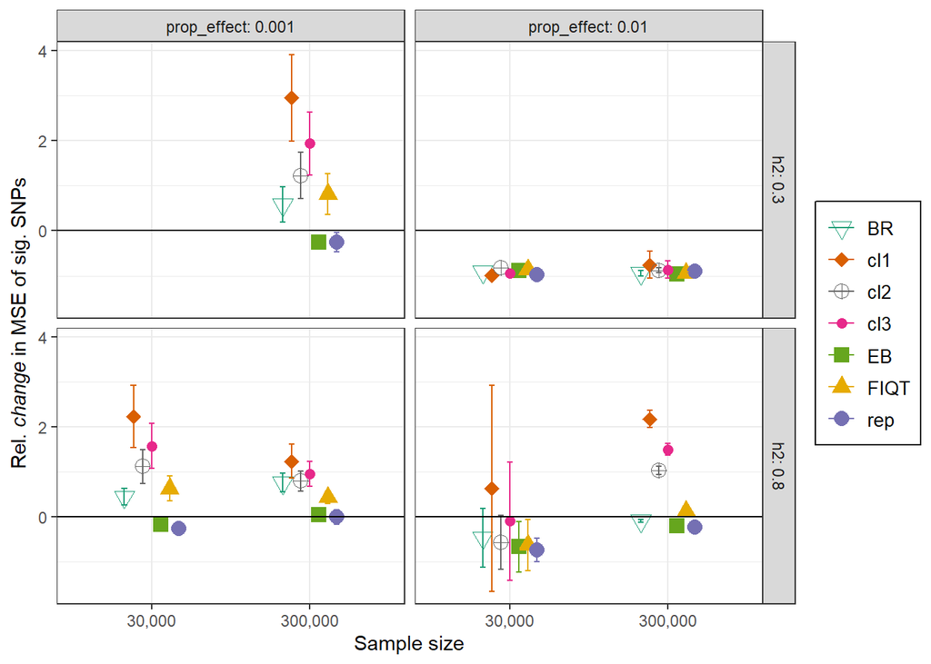

$~$ $~$ $~$ $~$

Note the absence of data for Scenario 13 in the above plot which is due to the fact that across all 10 simulations, no SNPs reached the significance threshold. Refer back to the first table in this section in order to gain an insight into the expected number of significant SNPs under each scenario. The plot above shows all methods performing extremely similarly in the top right corner but differences between the methods are clearly visible on the left in which again, it can be concluded that the empirical Bayes method behaves the best.

We also briefly look at the performance of methods at the lower threshold of $5 \times 10^{-4}$ for this binary trait. As one can see from the obtained plot, the results are as expected with all methods making improvements to the average MSE and the empirical Bayes method being the most reliable.

$~$ $~$ $~$ $~$

Summary of results for `rel_mse` contained in `binary_norm_5e-4_10sim.csv`:

| Scenario | n_samples | h2 | prop_effect | S | EB | FIQT | BR | cl1 | cl2 | cl3 | rep |
| --- | --- | --- | --- | --- | --- | --- | --- | --- | --- | --- | --- |
| 1 | 30,000 | 0.3 | 0.010 | -1 | -0.9941 | -0.9988 | -0.9147 | -0.8562 | -0.6989 | -0.7985 | -0.9300 |
| 2 | 300,000 | 0.3 | 0.010 | -1 | -0.9753 | -0.9777 | -0.9085 | -0.8461 | -0.7023 | -0.7959 | -0.9218 |
| 3 | 30,000 | 0.8 | 0.010 | -1 | -0.9080 | -0.9117 | -0.8659 | -0.8112 | -0.6997 | -0.7788 | -0.9099 |
| 4 | 300,000 | 0.8 | 0.010 | -1 | -0.3577 | -0.1615 | -0.2376 | -0.1789 | -0.3066 | -0.2761 | -0.6454 |
| 5 | 30,000 | 0.3 | 0.001 | -1 | -0.9907 | -0.9943 | -0.9130 | -0.8427 | -0.6935 | -0.7882 | -0.9280 |
| 6 | 300,000 | 0.3 | 0.001 | -1 | -0.8308 | -0.8050 | -0.7557 | -0.7759 | -0.6612 | -0.7417 | -0.9043 |
| 7 | 30,000 | 0.8 | 0.001 | -1 | -0.8103 | -0.7525 | -0.7035 | -0.7686 | -0.6481 | -0.7314 | -0.8896 |
| 8 | 300,000 | 0.8 | 0.001 | -1 | -0.7437 | -0.6824 | -0.5465 | -0.7248 | -0.5879 | -0.6805 | -0.8323 |
| 9 | 30,000 | 0.3 | 0.010 | 0 | -0.9954 | -0.9987 | -0.9134 | -0.8510 | -0.6963 | -0.7942 | -0.9299 |
| 10 | 300,000 | 0.3 | 0.010 | 0 | -0.9755 | -0.9775 | -0.9024 | -0.8420 | -0.6984 | -0.7915 | -0.9275 |
| 11 | 30,000 | 0.8 | 0.010 | 0 | -0.9191 | -0.9307 | -0.8659 | -0.8246 | -0.6966 | -0.7831 | -0.9154 |
| 12 | 300,000 | 0.8 | 0.010 | 0 | -0.4626 | -0.3698 | -0.3970 | -0.3819 | -0.4431 | -0.4437 | -0.7320 |
| 13 | 30,000 | 0.3 | 0.001 | 0 | -0.9932 | -0.9965 | -0.9120 | -0.8503 | -0.6966 | -0.7943 | -0.9299 |
| 14 | 300,000 | 0.3 | 0.001 | 0 | -0.8928 | -0.8802 | -0.8046 | -0.8170 | -0.6802 | -0.7708 | -0.9158 |
| 15 | 30,000 | 0.8 | 0.001 | 0 | -0.8400 | -0.8168 | -0.7571 | -0.7792 | -0.6582 | -0.7405 | -0.9031 |
| 16 | 300,000 | 0.8 | 0.001 | 0 | -0.7472 | -0.6972 | -0.5741 | -0.7391 | -0.6133 | -0.6978 | -0.8599 |
| 17 | 30,000 | 0.3 | 0.010 | 1 | -0.9962 | -0.9989 | -0.9136 | -0.8505 | -0.6966 | -0.7940 | -0.9294 |
| 18 | 300,000 | 0.3 | 0.010 | 1 | -0.9709 | -0.9739 | -0.9010 | -0.8378 | -0.6965 | -0.7881 | -0.9234 |
| 19 | 30,000 | 0.8 | 0.010 | 1 | -0.9072 | -0.9181 | -0.8523 | -0.8179 | -0.6914 | -0.7770 | -0.9155 |
| 20 | 300,000 | 0.8 | 0.010 | 1 | -0.5086 | -0.4340 | -0.4411 | -0.4843 | -0.4899 | -0.5149 | -0.7707 |
| 21 | 30,000 | 0.3 | 0.001 | 1 | -0.9913 | -0.9961 | -0.9128 | -0.8582 | -0.7000 | -0.8001 | -0.9274 |
| 22 | 300,000 | 0.3 | 0.001 | 1 | -0.8968 | -0.8857 | -0.8094 | -0.8129 | -0.6767 | -0.7661 | -0.9155 |
| 23 | 30,000 | 0.8 | 0.001 | 1 | -0.8700 | -0.8444 | -0.7759 | -0.7960 | -0.6664 | -0.7523 | -0.9048 |
| 24 | 300,000 | 0.8 | 0.001 | 1 | -0.7955 | -0.7539 | -0.6205 | -0.7730 | -0.6339 | -0.7268 | -0.8704 |

$~$ $~$ $~$ $~$

The *mean* relative change in average MSE over all significant SNPs across the 24 scenarios is obtained for each method:

```
##         EB       FIQT         BR        cl1        cl2        cl3        rep
## -0.8488708 -0.8231792 -0.7582708 -0.7550042 -0.6430125 -0.7219292 -0.8846625
```

The methods are ranked according to the results above in ascending order:

```
##   EB FIQT   BR  cl1  cl2  cl3  rep
##    2    3    4    5    7    6    1
```

$~$ $~$ $~$ $~$

*Relative change* **in average MSE over all significant SNPs due to method implementation for a** *binary* **trait, using a significance threshold of $5 \times 10^{-4}$:**

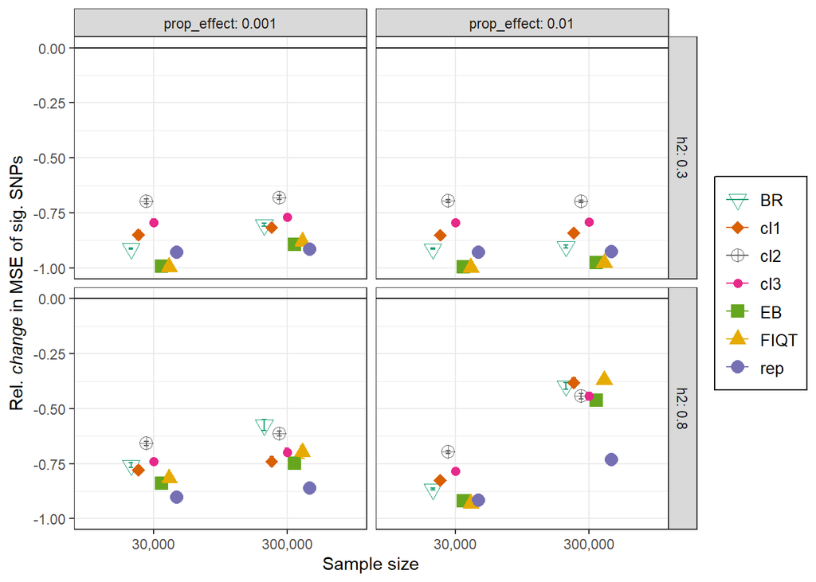

$~$ $~$ $~$ $~$

### 9. Comparison of the Empirical Bayes method with the true Bayes rule

In this section, we investigate comparing our empirical Bayes method with the true Bayes rule, given that our simulated true effect size distribution is used as the prior. This can allow us to identify the scenarios under which the empirical Bayes method performs almost optimally. If the effect sizes are standardized, i.e. we consider $z = \frac{\hat{\beta}}{\hat{se(\hat\beta)}}$, the true Bayes rule is known to be the optimal function of the data, at a single SNP, in minimizing population mean squared errors. In fact, it is also optimal in minimizing mean squared error over a subset of the data space, $\left| Z>c \right|$ say. The empirical Bayes approach aims to construct the Bayes rule. However, it fails to do this precisely as the exact marginal density of $z$-scores is not available.

If we denote the prior as $p(\mu)$ and the marginal density of $z$-scores as $f(z|\mu)$, then the Bayes rule is given as:
$$f(\mu|z) = \frac{p(\mu) f(z|\mu)}{\int{p(\mu) f(z|\mu) d\mu}}.$$
Thus, we can then write:
$$E(\mu | z) = \int{\mu f(\mu | z) d\mu} = \frac{\int{\mu p(\mu) f(z|\mu)}}{\int{p(\mu)f(z|\mu)}}.$$

As our prior, $p(\mu)$, has a point mass, it is difficult to integrate the above. Therefore, we choose to discretize the range of $\mu$s and calculate these integrals via summation. We then obtain:
$$E(\mu | z) = \frac{\sum\mu_{\text{mid}} \cdot p(\mu_{\text{mid}}) \cdot \phi(z - \mu_{mid})}{\sum p(\mu_{\text{mid}}) \cdot \phi(z-\mu_{\text{mid}})}$$
in which $\mu_{\text{mid}}$ is the midpoint of the interval, $p(\mu_{\text{mid}})$ is the fraction of total SNPs falling in that interval and $\phi$ is the standard normal density.

We first perform similar simulations to as those in previous sections with a normal effect size distribution, computing the *mean* relative change in average MSE over all significant SNPs for both the empirical Bayes method and the true Bayes rule which we have described here.

Summary of results for `rel_mse` contained in `norm_5e-8_10sim_bayes_compare.csv`:

| Scenario | n_samples | h2 | prop_effect | S | EB | bayes | rep |
| --- | --- | --- | --- | --- | --- | --- | --- |
| 1 | 30,000 | 0.3 | 0.010 | -1 | -0.6882 | -0.7705 | -0.9846 |
| 2 | 300,000 | 0.3 | 0.010 | -1 | -0.3039 | -0.3272 | -0.2882 |
| 3 | 30,000 | 0.8 | 0.010 | -1 | -0.6578 | -0.8129 | -0.7883 |
| 4 | 300,000 | 0.8 | 0.010 | -1 | -0.0822 | -0.0992 | -0.0425 |
| 5 | 30,000 | 0.3 | 0.001 | -1 | -0.1343 | -0.2759 | -0.2324 |
| 6 | 300,000 | 0.3 | 0.001 | -1 | 0.0362 | -0.0369 | 0.0439 |
| 7 | 30,000 | 0.8 | 0.001 | -1 | 0.0393 | -0.1207 | -0.0825 |
| 8 | 300,000 | 0.8 | 0.001 | -1 | 0.0787 | -0.0273 | -0.0052 |
| 9 | 30,000 | 0.3 | 0.010 | 0 | -0.6875 | -0.9251 | -0.6995 |
| 10 | 300,000 | 0.3 | 0.010 | 0 | -0.2877 | -0.3153 | -0.3129 |
| 11 | 30,000 | 0.8 | 0.010 | 0 | -0.6383 | -0.7271 | -0.7218 |
| 12 | 300,000 | 0.8 | 0.010 | 0 | -0.0966 | -0.1113 | -0.1277 |
| 13 | 30,000 | 0.3 | 0.001 | 0 | -0.1844 | -0.2828 | -0.2980 |
| 14 | 300,000 | 0.3 | 0.001 | 0 | 0.0482 | -0.0463 | 0.0126 |
| 15 | 30,000 | 0.8 | 0.001 | 0 | 0.0058 | -0.1168 | -0.0662 |
| 16 | 300,000 | 0.8 | 0.001 | 0 | 0.1245 | -0.0241 | -0.0364 |
| 17 | 30,000 | 0.3 | 0.010 | 1 | -0.6981 | -0.9261 | -0.8833 |
| 18 | 300,000 | 0.3 | 0.010 | 1 | -0.2217 | -0.2493 | -0.2487 |
| 19 | 30,000 | 0.8 | 0.010 | 1 | -0.5748 | -0.6841 | -0.6226 |
| 20 | 300,000 | 0.8 | 0.010 | 1 | -0.0721 | -0.0904 | -0.0740 |
| 21 | 30,000 | 0.3 | 0.001 | 1 | -0.1841 | -0.3184 | -0.2900 |
| 22 | 300,000 | 0.3 | 0.001 | 1 | 0.0408 | -0.0386 | -0.0108 |
| 23 | 30,000 | 0.8 | 0.001 | 1 | 0.0218 | -0.1025 | -0.1438 |
| 24 | 300,000 | 0.8 | 0.001 | 1 | 0.1391 | -0.0301 | -0.0311 |

$~$ $~$ $~$ $~$

The *mean* relative change in average MSE over all significant SNPs across the 24 scenarios is obtained for each method:

```
##         EB      bayes        rep
## -0.2073875 -0.3107875 -0.2889167
```

The methods are ranked according to the results above in ascending order:

```
##    EB bayes   rep
##     3     1     2
```

$~$ $~$ $~$ $~$

*Relative change* **in average MSE over all significant SNPs due to method implementation, using a significance threshold of $5 \times 10^{-8}$:**

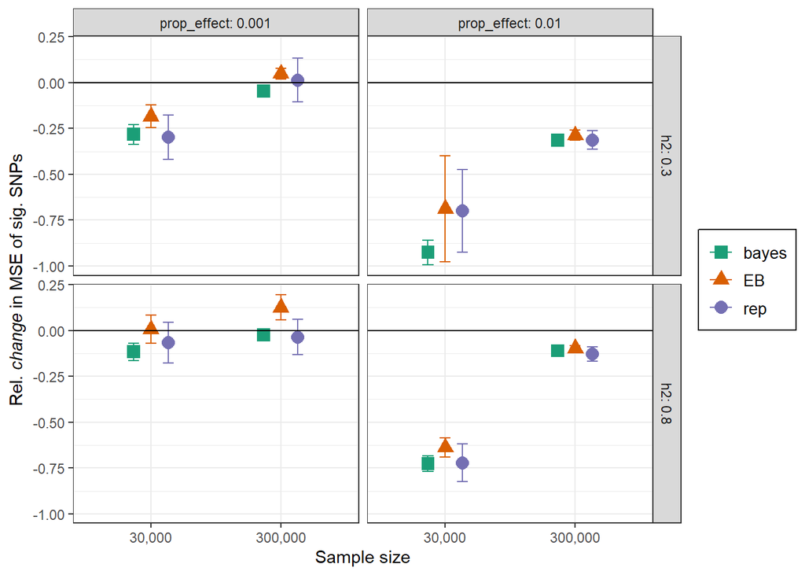

$~$ $~$ $~$ $~$

The above table and plots give us an idea in which scenarios the empirical Bayes method performs well. Next, we consider computing
$$\frac{\text{MSE}_{\text{EB}}}{\text{MSE}_{\text{Bayes}}} = \frac{\frac{1}{n} \sum^n_{i=1} (\hat\beta_{\text{EB,}i} - \beta_i)^2}{\frac{1}{n} \sum^n_{i=1} (\hat\beta_{\text{Bayes,}i} - \beta_i)^2}$$
over the top 10 significant SNPs and the top 100 significant SNPs. We calculate this for all of the various distributions that we have looked at for a quantitative trait: normal, bimodal and skewed. Ideally, we would like this value to be very close to 1.

As accurate implementation of the true Bayes rule can be very computationally intensive, we only consider 10 simulations for each scenario. The results contained in `EB_perform_measure_rank_10sim.csv` are summarised as follows, in which the first set of results relate to the situation in which we have focused on the top 10 significant SNPs.

| Scenario | n_samples | h2 | prop_effect | S | normal | bimodal | skewed | normal_sd | bimodal_sd | skewed_sd |
| --- | --- | --- | --- | --- | --- | --- | --- | --- | --- | --- |
| 1 | 30,000 | 0.3 | 0.010 | -1 | 1.166230 | 1.677833 | 1.206324 | 0.1255535 | 0.9796599 | 0.2534661 |
| 2 | 300,000 | 0.3 | 0.010 | -1 | 1.471611 | 1.483499 | 1.656327 | 0.5375771 | 0.6189517 | 0.8553098 |
| 3 | 30,000 | 0.8 | 0.010 | -1 | 1.909985 | 3.225993 | 1.359914 | 1.0760616 | 1.5469390 | 0.2001791 |
| 4 | 300,000 | 0.8 | 0.010 | -1 | 1.705694 | 1.428164 | 1.837020 | 0.9572154 | 0.4977849 | 0.4935901 |
| 5 | 30,000 | 0.3 | 0.001 | -1 | 2.046376 | 2.108182 | 1.995328 | 1.4810333 | 1.3271503 | 1.3178954 |
| 6 | 300,000 | 0.3 | 0.001 | -1 | 1.780172 | 1.356665 | 2.517830 | 1.0029173 | 0.4893220 | 1.7187140 |
| 7 | 30,000 | 0.8 | 0.001 | -1 | 1.464262 | 1.393074 | 1.341620 | 0.5442891 | 0.4046312 | 0.5507698 |
| 8 | 300,000 | 0.8 | 0.001 | -1 | 2.641975 | 1.815678 | 4.455489 | 1.2075220 | 0.7284937 | 3.7273287 |
| 9 | 30,000 | 0.3 | 0.010 | 0 | 1.156888 | 1.454758 | 2.097570 | 0.2799766 | 0.4868177 | 1.0509744 |
| 10 | 300,000 | 0.3 | 0.010 | 0 | 1.607642 | 1.401965 | 1.403415 | 0.9360957 | 0.9542742 | 0.3449074 |
| 11 | 30,000 | 0.8 | 0.010 | 0 | 1.763451 | 2.278576 | 1.608019 | 0.6978186 | 1.2503681 | 1.2541801 |
| 12 | 300,000 | 0.8 | 0.010 | 0 | 1.560427 | 1.455779 | 1.561998 | 0.7669697 | 0.5088342 | 0.6724982 |
| 13 | 30,000 | 0.3 | 0.001 | 0 | 1.437030 | 1.905480 | 1.421845 | 0.4848417 | 1.0514520 | 0.4054538 |
| 14 | 300,000 | 0.3 | 0.001 | 0 | 1.715443 | 1.231613 | 1.459006 | 1.0620966 | 0.3059286 | 0.4450302 |
| 15 | 30,000 | 0.8 | 0.001 | 0 | 1.452575 | 1.639955 | 1.951255 | 0.5803931 | 0.4653082 | 1.3622571 |
| 16 | 300,000 | 0.8 | 0.001 | 0 | 3.379545 | 1.112504 | 6.509860 | 5.4656086 | 0.1862336 | 5.1095419 |
| 17 | 30,000 | 0.3 | 0.010 | 1 | 2.432752 | 1.710827 | 1.667990 | 2.7763218 | 0.4233273 | 1.2492836 |
| 18 | 300,000 | 0.3 | 0.010 | 1 | 1.459157 | 1.499215 | 1.436414 | 0.6463815 | 0.4960978 | 0.6406549 |
| 19 | 30,000 | 0.8 | 0.010 | 1 | 1.683912 | 3.315061 | 1.574523 | 0.5266730 | 2.0317754 | 0.7813987 |
| 20 | 300,000 | 0.8 | 0.010 | 1 | 1.551891 | 2.594000 | 2.370936 | 0.5598723 | 3.8906193 | 2.7493961 |
| 21 | 30,000 | 0.3 | 0.001 | 1 | 1.578968 | 1.771572 | 1.570032 | 0.5702968 | 1.1153325 | 0.5710515 |
| 22 | 300,000 | 0.3 | 0.001 | 1 | 1.673532 | 1.076789 | 1.818851 | 0.9970379 | 0.1782015 | 1.5216255 |
| 23 | 30,000 | 0.8 | 0.001 | 1 | 1.535880 | 1.223222 | 1.591930 | 0.6049276 | 0.2794353 | 0.7584958 |
| 24 | 300,000 | 0.8 | 0.001 | 1 | 3.255694 | 1.448891 | 6.541511 | 4.5413410 | 0.4495399 | 8.7186407 |

$~$ $~$

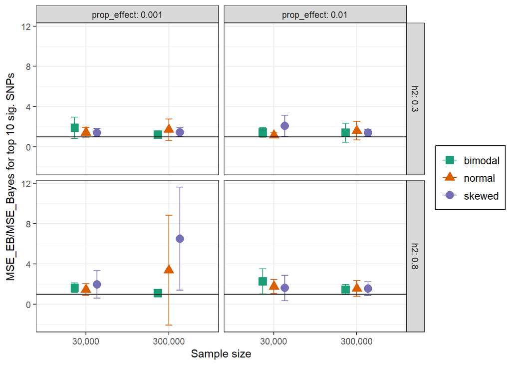

$~$ $~$

The following summarizes the results in which calculation of the above quantity has taken place over the top 100 significant SNPs.

| Scenario | n_samples | h2 | prop_effect | S | normal | bimodal | skewed | normal_sd | bimodal_sd | skewed_sd |
| --- | --- | --- | --- | --- | --- | --- | --- | --- | --- | --- |
| 1 | 30,000 | 0.3 | 0.010 | -1 | 1.077840 | 1.390462 | 1.065162 | 0.1793662 | 0.4619646 | 0.0551203 |
| 2 | 300,000 | 0.3 | 0.010 | -1 | 1.111286 | 1.092204 | 1.082551 | 0.0953387 | 0.1541319 | 0.0935798 |
| 3 | 30,000 | 0.8 | 0.010 | -1 | 1.159393 | 1.329251 | 1.281773 | 0.1982282 | 0.4010080 | 0.1780539 |
| 4 | 300,000 | 0.8 | 0.010 | -1 | 1.110467 | 1.110436 | 1.114169 | 0.0943268 | 0.0951335 | 0.0574113 |
| 5 | 30,000 | 0.3 | 0.001 | -1 | 1.195522 | 1.322232 | 1.388440 | 0.1158327 | 0.1698202 | 0.2289881 |
| 6 | 300,000 | 0.3 | 0.001 | -1 | 1.084034 | 1.109315 | 1.196692 | 0.0600986 | 0.0527482 | 0.1296412 |
| 7 | 30,000 | 0.8 | 0.001 | -1 | 1.114458 | 1.178906 | 1.126108 | 0.1232412 | 0.1322080 | 0.1197716 |
| 8 | 300,000 | 0.8 | 0.001 | -1 | 1.110076 | 1.105110 | 1.166228 | 0.1107375 | 0.1366918 | 0.0966377 |
| 9 | 30,000 | 0.3 | 0.010 | 0 | 1.010635 | 1.274389 | 1.153923 | 0.0891226 | 0.1439829 | 0.2149418 |
| 10 | 300,000 | 0.3 | 0.010 | 0 | 1.117258 | 1.095128 | 1.131893 | 0.0987392 | 0.1318323 | 0.0874516 |
| 11 | 30,000 | 0.8 | 0.010 | 0 | 1.194080 | 1.275033 | 1.097254 | 0.0828498 | 0.3464402 | 0.0941091 |
| 12 | 300,000 | 0.8 | 0.010 | 0 | 1.110527 | 1.182468 | 1.075199 | 0.0703141 | 0.0933012 | 0.0609922 |
| 13 | 30,000 | 0.3 | 0.001 | 0 | 1.124834 | 1.275384 | 1.238686 | 0.0731401 | 0.2514097 | 0.1351523 |
| 14 | 300,000 | 0.3 | 0.001 | 0 | 1.090223 | 1.095560 | 1.080097 | 0.0581932 | 0.0811878 | 0.0468561 |
| 15 | 30,000 | 0.8 | 0.001 | 0 | 1.079863 | 1.092158 | 1.108830 | 0.0620473 | 0.0478931 | 0.0883476 |
| 16 | 300,000 | 0.8 | 0.001 | 0 | 1.138011 | 1.043726 | 1.164131 | 0.0876798 | 0.0391459 | 0.0769364 |
| 17 | 30,000 | 0.3 | 0.010 | 1 | 1.178713 | 1.481097 | 1.392768 | 0.5302429 | 0.2155324 | 0.2663956 |
| 18 | 300,000 | 0.3 | 0.010 | 1 | 1.118207 | 1.071104 | 1.069274 | 0.0628779 | 0.1091068 | 0.0682092 |
| 19 | 30,000 | 0.8 | 0.010 | 1 | 1.118605 | 1.384575 | 1.077517 | 0.0603786 | 0.2745062 | 0.0777677 |
| 20 | 300,000 | 0.8 | 0.010 | 1 | 1.099663 | 1.163431 | 1.106971 | 0.0680123 | 0.2049524 | 0.0703196 |
| 21 | 30,000 | 0.3 | 0.001 | 1 | 1.196699 | 1.271696 | 1.326487 | 0.0961744 | 0.2584067 | 0.2645015 |
| 22 | 300,000 | 0.3 | 0.001 | 1 | 1.109491 | 1.070848 | 1.100190 | 0.0597313 | 0.0443928 | 0.0710116 |
| 23 | 30,000 | 0.8 | 0.001 | 1 | 1.123545 | 1.172716 | 1.098668 | 0.0873469 | 0.1954271 | 0.0675560 |
| 24 | 300,000 | 0.8 | 0.001 | 1 | 1.102626 | 1.064699 | 1.192257 | 0.0576749 | 0.0553870 | 0.0962807 |

$~$ $~$

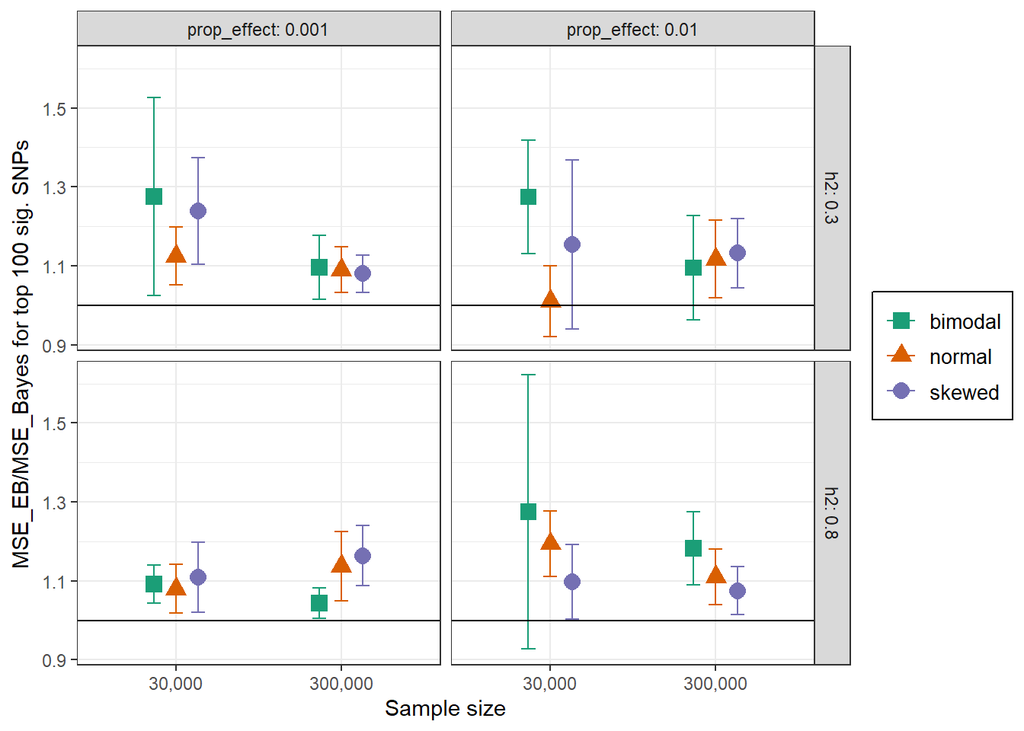

$~$ $~$

### 10. Measuring the degree of Winner’s Curse across the various scenarios

In this final section, using 100 simulations, we have computed
$$\frac{\text{MSE}_{\text{naive}}}{\text{MSE}_{\text{rep}}} = \frac{\frac{1}{n} \sum^n_{i=1} (\hat\beta_{\text{naive,}i} - \beta_i)^2}{\frac{1}{n} \sum^n_{i=1} (\hat\beta_{\text{rep,}i} - \beta_i)^2}$$
over the top 10 significant SNPs and the top 100 significant SNPs for each combination of our considered scenarios and three effect size distributions: normal, skewed and bimodal, for a quantitative trait. This can be thought of as a measure of the extent of the winner’s curse induced bias in each case, in which it is important to note that the number of samples in the replication data set is equivalent to that in the discovery. As above, the first set of results relate to where we have looked at just the top 10 significant SNPs. Note that we have merely plotted results for neutral selection as we have witnessed that the selection coefficient, S does not seem to have a great impact on our findings. The results are contained in `wc_measure_rank_100sim.csv`.

| Scenario | n_samples | h2 | prop_effect | S | normal | bimodal | skewed | normal_sd | bimodal_sd | skewed_sd |
| --- | --- | --- | --- | --- | --- | --- | --- | --- | --- | --- |
| 1 | 30,000 | 0.3 | 0.010 | -1 | 1688.24266 | 19.787619 | 1.955481 | 1355.21976 | 15.650308 | 1.2801548 |
| 2 | 300,000 | 0.3 | 0.010 | -1 | 208.60294 | 3.321824 | 1.267622 | 322.73474 | 2.318466 | 1.0139273 |
| 3 | 30,000 | 0.8 | 0.010 | -1 | 539.80967 | 6.786095 | 1.477036 | 423.90066 | 4.198951 | 1.0207054 |
| 4 | 300,000 | 0.8 | 0.010 | -1 | 99.75499 | 2.085195 | 1.348859 | 178.60773 | 1.307767 | 0.9221555 |
| 5 | 30,000 | 0.3 | 0.001 | -1 | 92.49923 | 2.656958 | 1.331883 | 118.45906 | 1.918059 | 0.9827028 |
| 6 | 300,000 | 0.3 | 0.001 | -1 | 37.25727 | 1.593595 | 1.249681 | 136.75122 | 1.140695 | 0.9882960 |
| 7 | 30,000 | 0.8 | 0.001 | -1 | 44.95981 | 1.869941 | 1.144372 | 114.75586 | 1.730114 | 0.8437357 |
| 8 | 300,000 | 0.8 | 0.001 | -1 | 40.53117 | 1.363860 | 1.192401 | 131.66549 | 1.057502 | 0.9323508 |
| 9 | 30,000 | 0.3 | 0.010 | 0 | 1405.01470 | 21.610053 | 3.449326 | 984.72656 | 14.588161 | 2.0180696 |
| 10 | 300,000 | 0.3 | 0.010 | 0 | 134.78144 | 3.757116 | 1.547993 | 208.74785 | 2.398669 | 1.1169315 |
| 11 | 30,000 | 0.8 | 0.010 | 0 | 357.07220 | 7.239248 | 2.146114 | 307.01830 | 4.386724 | 1.7570459 |
| 12 | 300,000 | 0.8 | 0.010 | 0 | 65.46227 | 2.128063 | 1.371596 | 122.73255 | 1.480455 | 0.9328932 |
| 13 | 30,000 | 0.3 | 0.001 | 0 | 67.04705 | 2.846272 | 1.478533 | 91.85743 | 2.353608 | 1.0739156 |
| 14 | 300,000 | 0.3 | 0.001 | 0 | 29.07070 | 1.555054 | 1.420602 | 120.01830 | 1.290980 | 1.1915543 |
| 15 | 30,000 | 0.8 | 0.001 | 0 | 40.87481 | 1.996789 | 1.394440 | 142.31656 | 1.399929 | 1.0362272 |
| 16 | 300,000 | 0.8 | 0.001 | 0 | 42.32362 | 1.464834 | 1.225404 | 102.18958 | 1.134726 | 0.7881298 |
| 17 | 30,000 | 0.3 | 0.010 | 1 | 1037.15832 | 22.790597 | 3.376803 | 841.36659 | 11.649784 | 2.9980603 |
| 18 | 300,000 | 0.3 | 0.010 | 1 | 113.55941 | 4.573857 | 1.496025 | 147.34966 | 2.709950 | 1.0888147 |
| 19 | 30,000 | 0.8 | 0.010 | 1 | 258.17991 | 8.334714 | 1.866540 | 201.03694 | 5.009989 | 1.1586994 |
| 20 | 300,000 | 0.8 | 0.010 | 1 | 67.30982 | 2.892061 | 1.298582 | 131.61855 | 1.949681 | 0.8997978 |
| 21 | 30,000 | 0.3 | 0.001 | 1 | 82.05100 | 3.237133 | 1.407467 | 131.53846 | 1.893196 | 0.8541272 |
| 22 | 300,000 | 0.3 | 0.001 | 1 | 19.97655 | 1.604745 | 1.183266 | 67.11512 | 1.049746 | 0.7182525 |
| 23 | 30,000 | 0.8 | 0.001 | 1 | 51.26544 | 2.211975 | 1.376752 | 119.20284 | 1.700109 | 1.4204723 |
| 24 | 300,000 | 0.8 | 0.001 | 1 | 23.40755 | 1.351643 | 1.169103 | 78.99384 | 1.142952 | 0.9885708 |

$~$ $~$

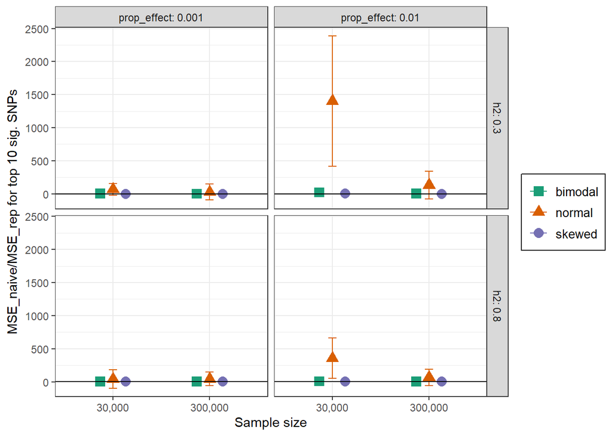

$~$ $~$

The following summarizes the results in which calculation of the above quantity has taken place over the top 100 significant SNPs.

| Scenario | n_samples | h2 | prop_effect | S | normal | bimodal | skewed | normal_sd | bimodal_sd | skewed_sd |
| --- | --- | --- | --- | --- | --- | --- | --- | --- | --- | --- |
| 1 | 30,000 | 0.3 | 0.010 | -1 | 1349.002721 | 15.455709 | 7.805059 | 342.07503 | 3.0922868 | 2.2669150 |
| 2 | 300,000 | 0.3 | 0.010 | -1 | 82.588187 | 2.191089 | 1.091363 | 53.14984 | 0.5264821 | 0.2296491 |
| 3 | 30,000 | 0.8 | 0.010 | -1 | 270.204416 | 4.731316 | 1.413777 | 92.99746 | 1.1924721 | 0.2967323 |
| 4 | 300,000 | 0.8 | 0.010 | -1 | 37.386157 | 1.454730 | 1.075362 | 39.36464 | 0.3695264 | 0.2022806 |
| 5 | 30,000 | 0.3 | 0.001 | -1 | 51.143941 | 1.526004 | 2.271527 | 58.05708 | 0.4040342 | 1.1513294 |
| 6 | 300,000 | 0.3 | 0.001 | -1 | 4.377120 | 1.050587 | 1.050456 | 26.45654 | 0.2611379 | 0.2661370 |
| 7 | 30,000 | 0.8 | 0.001 | -1 | 16.935720 | 1.235375 | 1.135007 | 32.54819 | 0.3387453 | 0.2879881 |
| 8 | 300,000 | 0.8 | 0.001 | -1 | 4.937821 | 1.094344 | 1.007145 | 33.53722 | 0.2733842 | 0.2321219 |
| 9 | 30,000 | 0.3 | 0.010 | 0 | 1431.395411 | 15.793851 | 10.669875 | 325.68564 | 3.7587844 | 2.7910610 |
| 10 | 300,000 | 0.3 | 0.010 | 0 | 61.124029 | 2.139436 | 1.240417 | 32.29882 | 0.3890420 | 0.2579088 |
| 11 | 30,000 | 0.8 | 0.010 | 0 | 226.144284 | 5.055997 | 1.792581 | 66.34339 | 1.2269354 | 0.3333283 |
| 12 | 300,000 | 0.8 | 0.010 | 0 | 23.851841 | 1.518107 | 1.096346 | 24.89611 | 0.2863594 | 0.2204981 |
| 13 | 30,000 | 0.3 | 0.001 | 0 | 44.265886 | 1.530823 | 1.411966 | 41.29385 | 0.3501654 | 0.4117327 |
| 14 | 300,000 | 0.3 | 0.001 | 0 | 1.044380 | 1.084746 | 1.050543 | 21.14990 | 0.2551600 | 0.2564159 |
| 15 | 30,000 | 0.8 | 0.001 | 0 | 13.975820 | 1.194687 | 1.135667 | 23.66739 | 0.2856091 | 0.2352106 |
| 16 | 300,000 | 0.8 | 0.001 | 0 | 4.098838 | 1.015275 | 1.040245 | 23.42288 | 0.2186874 | 0.2280822 |
| 17 | 30,000 | 0.3 | 0.010 | 1 | 1366.864327 | 16.922768 | 9.783348 | 283.26959 | 3.7531033 | 2.2798157 |
| 18 | 300,000 | 0.3 | 0.010 | 1 | 44.625342 | 2.556435 | 1.190314 | 28.47371 | 0.4049623 | 0.2218076 |
| 19 | 30,000 | 0.8 | 0.010 | 1 | 175.887658 | 5.995088 | 1.753848 | 84.80603 | 1.3117531 | 0.3879832 |
| 20 | 300,000 | 0.8 | 0.010 | 1 | 28.242040 | 1.804486 | 1.062767 | 29.17953 | 0.3509691 | 0.2229158 |
| 21 | 30,000 | 0.3 | 0.001 | 1 | 34.705279 | 1.562691 | 1.574336 | 52.89517 | 0.3317176 | 0.6296520 |
| 22 | 300,000 | 0.3 | 0.001 | 1 | 4.748525 | 1.068621 | 1.096226 | 21.56602 | 0.2022415 | 0.2515794 |
| 23 | 30,000 | 0.8 | 0.001 | 1 | 14.353714 | 1.225904 | 1.111149 | 23.90064 | 0.2490684 | 0.2322338 |
| 24 | 300,000 | 0.8 | 0.001 | 1 | 3.134111 | 1.044385 | 1.013476 | 20.91601 | 0.2298090 | 0.2494095 |

$~$ $~$

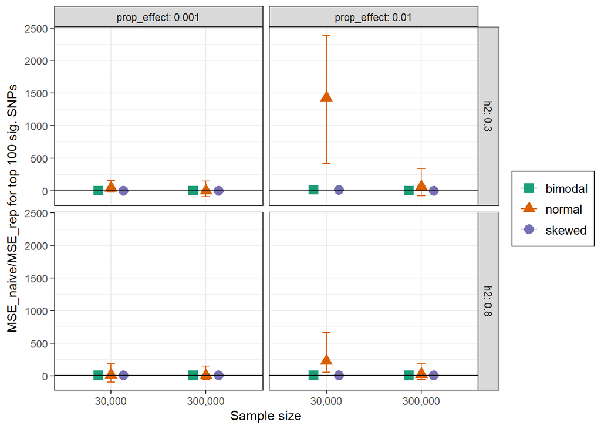

$~$ $~$

The fact that we witness in every scenario that the average of $\frac{\text{MSE}_{\text{naive}}}{\text{MSE}_{\text{rep}}}$ across our 100 simulations is greater than 1 is certain evidence of the existence of winner’s curse. However, the extent of the bias induced by winner’s curse varies drastically depending on the values of our parameters of interest and the distribution of true effects. Most noticeably, it is a normal effect size distribution that suffers the greatest out of our three considered distributions. In particular, a large degree of winner’s curse is seen when the heritability is 0.3, the proportion of true effect SNPs is 0.01 and we have 30,000 samples. This is the case for all three distributions. The same pattern is visible for the case in which we consider the top 10 SNPs and for the case in which we take a look at the top 100 SNPs. We chose to compare this metric for a fixed number of SNPs in each scenario instead of for just those SNPs that reached the specified threshold in each scenario to ensure that witnessed changes in $\frac{\text{MSE}_{\text{naive}}}{\text{MSE}_{\text{rep}}}$ were not due to the differing numbers of significant SNPs.

$~$ $~$